# R Notebook

#### Load frequently used packages

```r
library(skimr)
library(openxlsx)
library(ggrepel)
library(dplyr)
library(tidyr)
library(data.table)
library(broom)
library(broomExtra)
library(tibble)
library(sjstats)
library(car)
library(lme4)
library(lmerTest)
library(ggplot2)
library(tibble)
library(modelr)
library(tidyverse)
#library(miceadds)
library(ggforce)
require(openxlsx)
library(tidyverse)
library(caret)
library(glmnet)
library(ggplot2)
library(gridExtra)
library(MASS) # rlm
library(lmPerm)
library(circlize)
library(RColorBrewer)
library(ComplexHeatmap)

select <- dplyr::select
filter <- dplyr::filter
```

#### Setting and modifying theme for plots

```r
theme_set(theme_gray(base_size = 12, base_family = "Arial") +
            theme(panel.border = element_rect(colour="black", fill = "transparent"),
                  plot.title = element_text(face="bold", hjust = 0), # lineheight=.8, size=20,
                  axis.text = element_text(color="black", size = 11), #size = 14
                  axis.text.x = element_text(angle = 0, hjust = NULL),
                  strip.background = element_rect(colour="black", fill = "light grey", size = 1), # adjusts facet label borders (if any)
                  panel.background = element_blank(),
                  panel.grid = element_blank()
          ))
RedBlue <- c("#CD3333", "#1874CD")
GrayBlue <- c("grey", "#2b8cbe")
```

```bash
cp -a '/Users/shawjes/Dropbox/EspinosaGroup/ANALYSIS/Celiac_MultiOmics/GRS/DSMIG/051821_AbstractTable_HLADQ_Genotype_Frequencies_v0.1_JRS.xlsx' '/Users/shawjes/Dropbox/EspinosaGroup/ANALYSIS/Celiac_MultiOmics/GRS/DSMIG_Shared/Manuscript_Figure1/Data'
```

#### Define in/out directory

```r
dir <- '/Users/shawjes/Dropbox/EspinosaGroup/ANALYSIS/Celiac_MultiOmics/GRS/DSMIG_Shared/Manuscript_Figure1/Data'
dir.PCA <- '/Users/shawjes/Dropbox/EspinosaGroup/ANALYSIS/Celiac_MultiOmics/GRS/DSMIG_Shared/Manuscript_Figure1/Data/PCA'
dir.Results <- '/Users/shawjes/Dropbox/EspinosaGroup/ANALYSIS/Celiac_MultiOmics/GRS/DSMIG_Shared/Manuscript_Figure1/Results'
dir.Figures <- '/Users/shawjes/Dropbox/EspinosaGroup/ANALYSIS/Celiac_MultiOmics/GRS/DSMIG_Shared/Manuscript_Figure1/Figures'
dir.Tables <- '/Users/shawjes/Dropbox/EspinosaGroup/ANALYSIS/Celiac_MultiOmics/GRS/DSMIG_Shared/Manuscript_Figure1/Tables'
```

#### Read in frequencies for D21s as published in the Sharp paper

```r
setwd(dir)
HLADQ.freq_by_CD.D21 <- read.xlsx("051821_AbstractTable_HLADQ_Genotype_Frequencies_v0.1_JRS.xlsx") %>%
  separate(Freq_Controls_T21, into = c("Freq_Controls_T21", "N_Controls_T21"), sep = " ", extra = "merge", remove = TRUE) %>%
  separate(Freq_Cases_T21, into = c("Freq_Cases_T21", "N_Cases_T21"), sep = " ", extra = "merge", remove = TRUE) %>%
  mutate(N_Controls_T21 = gsub("[(]n[=]", "", N_Controls_T21),
         N_Controls_T21 = gsub("[)]", "", N_Controls_T21),
         N_Cases_T21 = gsub("[(]n[=]", "", N_Cases_T21),
         N_Cases_T21 = gsub("[)]", "", N_Cases_T21)) %>%
  select(HLA_DQ_Genotype, Freq_Controls_T21, Freq_Cases_T21, Freq_Controls_D21, Freq_Cases_D21) %>%
  unique() %>%
  gather(key = "Group", value = "Frequency", Freq_Controls_T21:Freq_Cases_D21) %>%
  mutate(Group = ifelse(Group == "Freq_Controls_T21", "T21 Controls",
                        ifelse(Group == "Freq_Cases_T21", "T21 Cases",
                               ifelse(Group == "Freq_Controls_D21", "D21 Controls",
                                      ifelse(Group == "Freq_Cases_D21", "D21 Cases", NA))))) %>%
  filter(grepl("T21", Group)==FALSE) %>%
  mutate(Group = ifelse(Group == "D21 Controls", "-DS -CD",
                        ifelse(Group == "D21 Cases", "-DS +CD", NA)))

HLADQ.freq_by_CD.D21
```

| HLA_DQ_Genotype | Group | Frequency |
| --- | --- | --- |
| DQ2.5/DQ2.5 | -DS -CD | 0.019 |
| DQ2.5/DQ2.2 | -DS -CD | 0.029 |
| DQ7.5/DQ2.2 | -DS -CD | 0.025 |
| DQ2.5/DQ8 | -DS -CD | 0.025 |
| DQ2.5/X | -DS -CD | 0.148 |
| DQ7.5/DQ2.5 | -DS -CD | 0.032 |
| DQ8/DQ8 | -DS -CD | 0.008 |
| DQ2.2/DQ8 | -DS -CD | 0.02 |
| DQ2.2/DQ2.2 | -DS -CD | 0.011 |
| DQ7.5/DQ8 | -DS -CD | 0.023 |

[output cut: 20 more lines]

#### Initialize an object to store the column names for the identifiers we want to keep in each analysis dataframe

```r
ID_colnames <- c("FamilyID", "RecordID", "MEGA.FID", "MEGA.IID", "MEGA.LabID")
```

#### Read in prepared metadata

```r
setwd(dir)
analysis_meta <- fread("MEGA_041822_META_CeliacGRS_v0.1_JRS.csv") %>%
  select(ID_colnames, Celiac, LabID, Celiac, EXCLUDE_from_analysis, EXCLUDE_reason) %>%
  unique()
```

```
Note: Using an external vector in selections is ambiguous.
ℹ Use `all_of(ID_colnames)` instead of `ID_colnames` to silence this message.
ℹ See <https://tidyselect.r-lib.org/reference/faq-external-vector.html>.
```

```r
analysis_meta
```

| FamilyID | RecordID | MEGA.FID | MEGA.IID | MEGA.LabID | Celiac | LabID | EXCLUDE_from_analysis | EXCLUDE_reason |
| --- | --- | --- | --- | --- | --- | --- | --- | --- |
| F0162 | INVJJ722DLC | 48 | WG1-DNA_A07_HTP0263A | HTP0263A | 0 | HTP0263A | 1 | FamilyID with multiple RecordIDs |
| F0084 | INVPH605CHL | 77 | WG1-DNA_F10_HTP0295A | HTP0295A | 0 | HTP0295A | 0 |  |
| F0162 | INVZH038AL1 | 39 | WG1-DNA_H05_HTP0262A | HTP0262A | 0 | HTP0262A | 0 |  |
| F0203 | INVZJ665XRL | 79 | WG1-DNA_H10_HTP0331A | HTP0331A | 0 | HTP0331A | 1 | FamilyID with multiple RecordIDs |
| F0084 | INVJZ695ZWX | 87 | WG1-DNA_H11_HTP0296A | HTP0296A | 0 | HTP0296A | 1 | FamilyID with multiple RecordIDs |
| F0348 | INVEM294KNC | 145 | WG2-DNA_F08_HTP0430A | HTP0430A | 0 | HTP0430A | 1 | FamilyID with multiple RecordIDs |
| F0337 | INVJR258URN | 159 | WG2-DNA_G10_HTP0480A | HTP0480A | 0 | HTP0480A | 0 |  |
| F0337 | INVKC254CTW | 201 | WG3-DNA_A05_HTP0483A | HTP0483A | 0 | HTP0483A | 1 | FamilyID with multiple RecordIDs |
| F0203 | INVZU346ZW0 | 190 | WG3-DNA_C03_HTP0333A3 | HTP0333A3 | 0 | HTP0333A | 0 |  |
| F0348 | INVTH328HA9 | 203 | WG3-DNA_C05_HTP0432A | HTP0432A | 1 | HTP0432A | 0 |  |

[output cut: 205 more lines]

#### Read in prepared analysis datasets and keep only the IDs included in analysis

```r
setwd(dir)
analysisData.GRS2019 <- fread("MEGA_041822_AnalysisData_CDGRS_Sharp2019_v0.1_JRS.csv") %>%
  left_join(analysis_meta, by = ID_colnames) %>%
  filter(EXCLUDE_from_analysis == 0)

analysisData.GRS2022 <- fread("MEGA_041822_AnalysisData_CDGRS_Sharp2022_v0.1_JRS.csv") %>%
  left_join(analysis_meta, by = ID_colnames) %>%
  filter(EXCLUDE_from_analysis == 0)

analysisData.GRS2019
```

| GRS_version | GRS_reference | FamilyID | RecordID | MEGA.FID | MEGA.IID | MEGA.LabID | Variant (Sharp 2019) | Score_Allele | Dosage_for_GRS | Score_Weight (logOR) | Putative Gene (Sharp 2019) | Weight x Dosage | GRS | CHR.GRCh37 | POS.GRCh37 | REF.FWD | ALT.FWD | MIS_VCF_INFO.AF | MIS_VCF_INFO.MAF | MIS_VCF_INFO.R2 | MIS_VCF_INFO.ER2 | Celiac | LabID | EXCLUDE_from_analysis | EXCLUDE_reason |
| --- | --- | --- | --- | --- | --- | --- | --- | --- | --- | --- | --- | --- | --- | --- | --- | --- | --- | --- | --- | --- | --- | --- | --- | --- | --- |
| Sharp et al., 2019 | PMID: 32790217 DOI: 10.1111/apt.15826 | F0123 | INVJH781GU1 | 16 | WG1-DNA_A03_HTP0215A | HTP0215A | rs61579022 | A | 1 | 0.104 | ARHGAP31 | 0.104 | 0.864 | 3 | 119123278 | G | A | 0.38702 | 0.38702 | 0.99514 | NA | 0 | HTP0215A | 0 |  |
| Sharp et al., 2019 | PMID: 32790217 DOI: 10.1111/apt.15826 | F0070 | INVWC975XJD | 24 | WG1-DNA_A04_HTP0139A | HTP0139A | rs61579022 | A | 0 | 0.104 | ARHGAP31 | 0.000 | 0.293 | 3 | 119123278 | G | A | 0.38702 | 0.38702 | 0.99514 | NA | 0 | HTP0139A | 0 |  |
| Sharp et al., 2019 | PMID: 32790217 DOI: 10.1111/apt.15826 | F0161 | INVEK756HK4 | 32 | WG1-DNA_A05_HTP0261A | HTP0261A | rs61579022 | A | 0 | 0.104 | ARHGAP31 | 0.000 | 5.997 | 3 | 119123278 | G | A | 0.38702 | 0.38702 | 0.99514 | NA | 1 | HTP0261A | 0 |  |
| Sharp et al., 2019 | PMID: 32790217 DOI: 10.1111/apt.15826 | F0160 | INVKR401EB8 | 56 | WG1-DNA_A08_HTP0260A | HTP0260A | rs61579022 | A | 0 | 0.104 | ARHGAP31 | 0.000 | 2.217 | 3 | 119123278 | G | A | 0.38702 | 0.38702 | 0.99514 | NA | 0 | HTP0260A | 0 |  |
| Sharp et al., 2019 | PMID: 32790217 DOI: 10.1111/apt.15826 | F0188 | INVPD049AAT | 64 | WG1-DNA_A09_HTP0318A | HTP0318A | rs61579022 | A | 1 | 0.104 | ARHGAP31 | 0.104 | 1.236 | 3 | 119123278 | G | A | 0.38702 | 0.38702 | 0.99514 | NA | 0 | HTP0318A | 0 |  |
| Sharp et al., 2019 | PMID: 32790217 DOI: 10.1111/apt.15826 | F0187 | INVNR591FH5 | 72 | WG1-DNA_A10_HTP0310A | HTP0310A | rs61579022 | A | 2 | 0.104 | ARHGAP31 | 0.208 | 1.349 | 3 | 119123278 | G | A | 0.38702 | 0.38702 | 0.99514 | NA | 0 | HTP0310A | 0 |  |
| Sharp et al., 2019 | PMID: 32790217 DOI: 10.1111/apt.15826 | F0008 | INVXV276GTA | 80 | WG1-DNA_A11_HTP0012A2 | HTP0012A2 | rs61579022 | A | 0 | 0.104 | ARHGAP31 | 0.000 | 0.993 | 3 | 119123278 | G | A | 0.38702 | 0.38702 | 0.99514 | NA | 0 | HTP0012A | 0 |  |
| Sharp et al., 2019 | PMID: 32790217 DOI: 10.1111/apt.15826 | F0081 | INVZZ627KNQ | 2 | WG1-DNA_B01_HTP0207A | HTP0207A | rs61579022 | A | 2 | 0.104 | ARHGAP31 | 0.208 | 4.455 | 3 | 119123278 | G | A | 0.38702 | 0.38702 | 0.99514 | NA | 0 | HTP0207A | 0 |  |
| Sharp et al., 2019 | PMID: 32790217 DOI: 10.1111/apt.15826 | F0130 | INVGV013LCP | 9 | WG1-DNA_B02_HTP0223A | HTP0223A | rs61579022 | A | 2 | 0.104 | ARHGAP31 | 0.208 | 4.082 | 3 | 119123278 | G | A | 0.38702 | 0.38702 | 0.99514 | NA | 0 | HTP0223A | 0 |  |
| Sharp et al., 2019 | PMID: 32790217 DOI: 10.1111/apt.15826 | F0164 | INVRD721DGJ | 17 | WG1-DNA_B03_HTP0265A | HTP0265A | rs61579022 | A | 2 | 0.104 | ARHGAP31 | 0.208 | 1.709 | 3 | 119123278 | G | A | 0.38702 | 0.38702 | 0.99514 | NA | 0 | HTP0265A | 0 |  |

[output cut: 990 more lines]

```r
analysisData.GRS2022
```

| GRS_version | GRS_reference | FamilyID | RecordID | MEGA.FID | MEGA.IID | MEGA.LabID | Variant (Sharp 2022) | Score_Allele | Dosage_for_GRS | Score_Weight (logOR) | Putative Gene (Sharp 2019) | Weight x Dosage | GRS | CHR.GRCh37 | POS.GRCh37 | REF.FWD | ALT.FWD | MIS_VCF_INFO.AF | MIS_VCF_INFO.MAF | MIS_VCF_INFO.R2 | MIS_VCF_INFO.ER2 | Celiac | LabID | EXCLUDE_from_analysis | EXCLUDE_reason |
| --- | --- | --- | --- | --- | --- | --- | --- | --- | --- | --- | --- | --- | --- | --- | --- | --- | --- | --- | --- | --- | --- | --- | --- | --- | --- |
| Sharp et al., 2022 | https://github.com/sethsh7/hla-prs-toolkit | F0123 | INVJH781GU1 | 16 | WG1-DNA_A03_HTP0215A | HTP0215A | rs61579022 | A | 1 | 0.104 | ARHGAP31 | 0.104 | 0.864 | 3 | 119123278 | G | A | 0.38702 | 0.38702 | 0.99514 | NA | 0 | HTP0215A | 0 |  |
| Sharp et al., 2022 | https://github.com/sethsh7/hla-prs-toolkit | F0070 | INVWC975XJD | 24 | WG1-DNA_A04_HTP0139A | HTP0139A | rs61579022 | A | 0 | 0.104 | ARHGAP31 | 0.000 | 0.293 | 3 | 119123278 | G | A | 0.38702 | 0.38702 | 0.99514 | NA | 0 | HTP0139A | 0 |  |
| Sharp et al., 2022 | https://github.com/sethsh7/hla-prs-toolkit | F0161 | INVEK756HK4 | 32 | WG1-DNA_A05_HTP0261A | HTP0261A | rs61579022 | A | 0 | 0.104 | ARHGAP31 | 0.000 | 5.997 | 3 | 119123278 | G | A | 0.38702 | 0.38702 | 0.99514 | NA | 1 | HTP0261A | 0 |  |
| Sharp et al., 2022 | https://github.com/sethsh7/hla-prs-toolkit | F0160 | INVKR401EB8 | 56 | WG1-DNA_A08_HTP0260A | HTP0260A | rs61579022 | A | 0 | 0.104 | ARHGAP31 | 0.000 | 2.217 | 3 | 119123278 | G | A | 0.38702 | 0.38702 | 0.99514 | NA | 0 | HTP0260A | 0 |  |
| Sharp et al., 2022 | https://github.com/sethsh7/hla-prs-toolkit | F0188 | INVPD049AAT | 64 | WG1-DNA_A09_HTP0318A | HTP0318A | rs61579022 | A | 1 | 0.104 | ARHGAP31 | 0.104 | 1.236 | 3 | 119123278 | G | A | 0.38702 | 0.38702 | 0.99514 | NA | 0 | HTP0318A | 0 |  |
| Sharp et al., 2022 | https://github.com/sethsh7/hla-prs-toolkit | F0187 | INVNR591FH5 | 72 | WG1-DNA_A10_HTP0310A | HTP0310A | rs61579022 | A | 2 | 0.104 | ARHGAP31 | 0.208 | 1.349 | 3 | 119123278 | G | A | 0.38702 | 0.38702 | 0.99514 | NA | 0 | HTP0310A | 0 |  |
| Sharp et al., 2022 | https://github.com/sethsh7/hla-prs-toolkit | F0008 | INVXV276GTA | 80 | WG1-DNA_A11_HTP0012A2 | HTP0012A2 | rs61579022 | A | 0 | 0.104 | ARHGAP31 | 0.000 | 0.993 | 3 | 119123278 | G | A | 0.38702 | 0.38702 | 0.99514 | NA | 0 | HTP0012A | 0 |  |
| Sharp et al., 2022 | https://github.com/sethsh7/hla-prs-toolkit | F0081 | INVZZ627KNQ | 2 | WG1-DNA_B01_HTP0207A | HTP0207A | rs61579022 | A | 2 | 0.104 | ARHGAP31 | 0.208 | 4.455 | 3 | 119123278 | G | A | 0.38702 | 0.38702 | 0.99514 | NA | 0 | HTP0207A | 0 |  |
| Sharp et al., 2022 | https://github.com/sethsh7/hla-prs-toolkit | F0130 | INVGV013LCP | 9 | WG1-DNA_B02_HTP0223A | HTP0223A | rs61579022 | A | 2 | 0.104 | ARHGAP31 | 0.208 | 4.082 | 3 | 119123278 | G | A | 0.38702 | 0.38702 | 0.99514 | NA | 0 | HTP0223A | 0 |  |
| Sharp et al., 2022 | https://github.com/sethsh7/hla-prs-toolkit | F0164 | INVRD721DGJ | 17 | WG1-DNA_B03_HTP0265A | HTP0265A | rs61579022 | A | 2 | 0.104 | ARHGAP31 | 0.208 | 1.709 | 3 | 119123278 | G | A | 0.38702 | 0.38702 | 0.99514 | NA | 0 | HTP0265A | 0 |  |

[output cut: 990 more lines]

#### Recall the number of Celiac cases and controls we have in our analysis cohort of T21s

[output not shown]

```r
analysisData.GRS2019 %>%
  select(RecordID, MEGA.IID, Celiac) %>%
  unique() %>%
  group_by(Celiac) %>%
  summarise(N = n())


analysisData.GRS2022 %>%
  select(RecordID, MEGA.IID, Celiac) %>%
  unique() %>%
  group_by(Celiac) %>%
  summarise(N = n())
```

| Celiac | N |
| --- | --- |
| 0 | 185 |
| 1 | 19 |

#### Calculate frequencies of HLA-DQ genotypes in the analysis cohort of T21s

##### For GRS 2019

[output not shown]

[output cut: 5 more lines]

```r
temp


# sum(temp$`DS with CD`)
# sum(temp$`DS without CD`)
# [1] 19
# [1] 182

HLADQ.freq_by_CD.T21.GRS2019 <- temp %>%
  mutate(Total_DS_without_CD = sum(temp$`DS without CD`),
         Total_DS_with_CD = sum(temp$`DS with CD`)) %>%
  mutate(Freq_among_DS_without_CD = round(`DS without CD`/Total_DS_without_CD, digits = 4),
         Freq_among_DS_with_CD = round(`DS with CD`/Total_DS_with_CD, digits = 4)) %>%
  mutate(`Frequency among DS without CD (%)` = paste(`DS without CD`, " (", Freq_among_DS_without_CD, ")", sep = ""),
         `Frequency among DS with CD (%)` = paste(`DS with CD`, " (", Freq_among_DS_with_CD, ")", sep = "")) %>%
  select(HLA_DQ_Genotype, `Frequency among DS without CD (%)`, `Frequency among DS with CD (%)`) %>%
  rename(`HLA-DQ genotype` = HLA_DQ_Genotype) %>%
  `colnames<-`(c("HLA-DQ genotype", "+DS -CD", "+DS +CD")) %>%
  gather(key = "Group", value = "Frequency", `+DS -CD`:`+DS +CD`) %>%
  separate(Frequency, into = c("N", "Frequency"), sep = " [(]", extra = "merge", remove = TRUE) %>%
  mutate(Frequency = gsub("[)]", "", Frequency))

HLADQ.freq_by_CD.T21.GRS2019
```

| HLA-DQ genotype | Group | N | Frequency |
| --- | --- | --- | --- |
| DQ2.5/DQ2.5 | +DS -CD | 0 | 0 |
| DQ2.5/DQ2.2 | +DS -CD | 4 | 0.0216 |
| DQ7.5/DQ2.2 | +DS -CD | 8 | 0.0432 |
| DQ2.5/DQ8 | +DS -CD | 2 | 0.0108 |
| DQ2.5/X | +DS -CD | 21 | 0.1135 |
| DQ7.5/DQ2.5 | +DS -CD | 16 | 0.0865 |
| DQ8/DQ8 | +DS -CD | 0 | 0 |
| DQ2.2/DQ8 | +DS -CD | 6 | 0.0324 |
| DQ2.2/DQ2.2 | +DS -CD | 0 | 0 |
| DQ7.5/DQ8 | +DS -CD | 7 | 0.0378 |

[output cut: 20 more lines]

##### For GRS 2022

```r
temp <- analysisData.GRS2022 %>%
  rename(Variant = `Variant (Sharp 2022)`, Dosage = Dosage_for_GRS) %>%
  mutate(Karyotype = ifelse(grepl("A", MEGA.LabID)==TRUE, "T21", "D21")) %>%
  select(MEGA.IID, Variant, Dosage, Celiac, Karyotype) %>%
  unique() %>%
  mutate(Group = ifelse(Karyotype == "T21" & Celiac == 0, "DS without CD",
                        ifelse(Karyotype == "T21" & Celiac == 1, "DS with CD", NA))) %>%
  select(-c(Celiac)) %>%
  group_by(Group, Variant, Dosage) %>%
  summarise(N = n()) %>%
  ungroup() %>%
  filter((grepl("DQ", Variant)==TRUE | Variant=="X/X") & Dosage != 0) %>%
  select(Variant, Group, N) %>%
  spread(key = Group, value = N) %>%
  # mutate(`DS without CD` = ifelse(is.na(`DS without CD`), 0, `DS without CD`),
  #        `DS with CD` = ifelse(is.na(`DS with CD`), 0, `DS with CD`)) %>%
  rename(HLA_DQ_Genotype = Variant) %>%
  full_join(HLADQ.freq_by_CD.D21 %>% select(HLA_DQ_Genotype) %>% unique() %>% mutate(row_num = row_number()), by = c("HLA_DQ_Genotype")) %>%
  mutate(`DS without CD` = ifelse(is.na(`DS without CD`), 0, `DS without CD`),
         `DS with CD` = ifelse(is.na(`DS with CD`), 0, `DS with CD`)) %>%
  arrange(row_num) %>%
  select(-c(row_num))
temp
```

| HLA_DQ_Genotype | DS with CD | DS without CD |
| --- | --- | --- |
| DQ2.5/DQ2.5 | 0 | 0 |
| DQ2.5/DQ2.2 | 1 | 4 |
| DQ7.5/DQ2.2 | 1 | 8 |
| DQ2.5/DQ8 | 1 | 2 |
| DQ2.5/X | 5 | 21 |
| DQ7.5/DQ2.5 | 1 | 16 |
| DQ8/DQ8 | 0 | 0 |
| DQ2.2/DQ8 | 3 | 6 |
| DQ2.2/DQ2.2 | 0 | 0 |
| DQ7.5/DQ8 | 1 | 7 |

[output cut: 5 more lines]

```r
# sum(temp$`DS with CD`)
# sum(temp$`DS without CD`)
# [1] 19
# [1] 182

HLADQ.freq_by_CD.T21.GRS2022 <- temp %>%
  mutate(Total_DS_without_CD = sum(temp$`DS without CD`),
         Total_DS_with_CD = sum(temp$`DS with CD`)) %>%
  mutate(Freq_among_DS_without_CD = round(`DS without CD`/Total_DS_without_CD, digits = 4),
         Freq_among_DS_with_CD = round(`DS with CD`/Total_DS_with_CD, digits = 4)) %>%
  mutate(`Frequency among DS without CD (%)` = paste(`DS without CD`, " (", Freq_among_DS_without_CD, ")", sep = ""),
         `Frequency among DS with CD (%)` = paste(`DS with CD`, " (", Freq_among_DS_with_CD, ")", sep = "")) %>%
  select(HLA_DQ_Genotype, `Frequency among DS without CD (%)`, `Frequency among DS with CD (%)`) %>%
  rename(`HLA-DQ genotype` = HLA_DQ_Genotype) %>%
  `colnames<-`(c("HLA-DQ genotype", "+DS -CD", "+DS +CD")) %>%
  gather(key = "Group", value = "Frequency", `+DS -CD`:`+DS +CD`) %>%
  separate(Frequency, into = c("N", "Frequency"), sep = " [(]", extra = "merge", remove = TRUE) %>%
  mutate(Frequency = gsub("[)]", "", Frequency))

HLADQ.freq_by_CD.T21.GRS2022
```

| HLA-DQ genotype | Group | N | Frequency |
| --- | --- | --- | --- |
| DQ2.5/DQ2.5 | +DS -CD | 0 | 0 |
| DQ2.5/DQ2.2 | +DS -CD | 4 | 0.0216 |
| DQ7.5/DQ2.2 | +DS -CD | 8 | 0.0432 |
| DQ2.5/DQ8 | +DS -CD | 2 | 0.0108 |
| DQ2.5/X | +DS -CD | 21 | 0.1135 |
| DQ7.5/DQ2.5 | +DS -CD | 16 | 0.0865 |
| DQ8/DQ8 | +DS -CD | 0 | 0 |
| DQ2.2/DQ8 | +DS -CD | 6 | 0.0324 |
| DQ2.2/DQ2.2 | +DS -CD | 0 | 0 |
| DQ7.5/DQ8 | +DS -CD | 7 | 0.0378 |

[output cut: 20 more lines]

#### Create a table that shows frequency of each HLA-DQ genotype among +/-DS +/-CD; Verify that within-group frequencies sum to 1; Output to file

##### GRS 2019

```r
`Permissive, high risk` = c("DQ2.5/DQ2.5", "DQ2.5/DQ2.2", "DQ7.5/DQ2.5")
`Permissive, intermediate risk` = c("DQ2.5/DQ8", "DQ7.5/DQ2.2", "DQ2.5/X", "DQ8/DQ8", "DQ2.2/DQ8", "DQ7.5/DQ8", "DQ8/X")
`Permissive low risk` = c("DQ2.2/X", "DQ2.2/DQ2.2")
`Non-permissive` = c("DQ7.5/DQ7.5", "DQ7.5/X", "X/X")

HLADQ_freq_by_CD.D21.T21.long.GRS2019 <- rbind(HLADQ.freq_by_CD.D21 %>%
                                         rename(`HLA-DQ genotype` = HLA_DQ_Genotype) %>%
                                         mutate(N = NA) %>%
                                         select(`HLA-DQ genotype`, Group, N, Frequency),
                                       HLADQ.freq_by_CD.T21.GRS2019
                                       ) %>%
  mutate(Frequency = as.numeric(Frequency)) %>%
  mutate(Genotype_category = ifelse(`HLA-DQ genotype` %in% `Permissive, high risk`, "Permissive, high risk",
                                   ifelse(`HLA-DQ genotype` %in% `Permissive, intermediate risk`, "Permissive, intermediate risk",
                                          ifelse(`HLA-DQ genotype` %in% `Permissive low risk`, "Permissive, low risk",
                                                 ifelse(`HLA-DQ genotype` %in% `Non-permissive`, "Non-permissive", NA)))),
         `HLA-DQ genotype` = factor(`HLA-DQ genotype`,
                                    levels = c("DQ2.5/DQ2.5", "DQ2.5/DQ2.2", "DQ7.5/DQ2.5",
                                               "DQ2.5/DQ8", "DQ7.5/DQ2.2", "DQ2.5/X", "DQ8/DQ8", "DQ2.2/DQ8", "DQ7.5/DQ8", "DQ8/X",
                                               "DQ2.2/X", "DQ2.2/DQ2.2",
                                               "DQ7.5/DQ7.5", "DQ7.5/X", "X/X")))

HLADQ_freq_by_CD.D21.T21.wide.GRS2019 <- HLADQ_freq_by_CD.D21.T21.long.GRS2019 %>%
  mutate(Frequency = ifelse(!is.na(N), paste(Frequency, " (n=", N, ")", sep = ""), Frequency)) %>%
  select(-N) %>%
  spread(key = Group, value = Frequency)

HLADQ_freq_by_CD.D21.T21.long.GRS2019
```

| HLA-DQ genotype | Group | N | Frequency | Genotype_category |
| --- | --- | --- | --- | --- |
| DQ2.5/DQ2.5 | -DS -CD | NA | 0.0190 | Permissive, high risk |
| DQ2.5/DQ2.2 | -DS -CD | NA | 0.0290 | Permissive, high risk |
| DQ7.5/DQ2.2 | -DS -CD | NA | 0.0250 | Permissive, intermediate risk |
| DQ2.5/DQ8 | -DS -CD | NA | 0.0250 | Permissive, intermediate risk |
| DQ2.5/X | -DS -CD | NA | 0.1480 | Permissive, intermediate risk |
| DQ7.5/DQ2.5 | -DS -CD | NA | 0.0320 | Permissive, high risk |
| DQ8/DQ8 | -DS -CD | NA | 0.0080 | Permissive, intermediate risk |
| DQ2.2/DQ8 | -DS -CD | NA | 0.0200 | Permissive, intermediate risk |
| DQ2.2/DQ2.2 | -DS -CD | NA | 0.0110 | Permissive, low risk |
| DQ7.5/DQ8 | -DS -CD | NA | 0.0230 | Permissive, intermediate risk |

[output cut: 50 more lines]

```r
HLADQ_freq_by_CD.D21.T21.wide.GRS2019
```

| HLA-DQ genotype | Genotype_category | -DS -CD | -DS +CD | +DS -CD | +DS +CD |
| --- | --- | --- | --- | --- | --- |
| DQ2.5/DQ2.5 | Permissive, high risk | 0.019 | 0.16 | 0 (n=0) | 0 (n=0) |
| DQ2.5/DQ2.2 | Permissive, high risk | 0.029 | 0.24 | 0.0216 (n=4) | 0.0526 (n=1) |
| DQ7.5/DQ2.5 | Permissive, high risk | 0.032 | 0.048 | 0.0865 (n=16) | 0.0526 (n=1) |
| DQ2.5/DQ8 | Permissive, intermediate risk | 0.025 | 0.06 | 0.0108 (n=2) | 0.0526 (n=1) |
| DQ7.5/DQ2.2 | Permissive, intermediate risk | 0.025 | 0.076 | 0.0432 (n=8) | 0.0526 (n=1) |
| DQ2.5/X | Permissive, intermediate risk | 0.148 | 0.309 | 0.1135 (n=21) | 0.2632 (n=5) |
| DQ8/DQ8 | Permissive, intermediate risk | 0.008 | 0.009 | 0 (n=0) | 0 (n=0) |
| DQ2.2/DQ8 | Permissive, intermediate risk | 0.02 | 0.016 | 0.0324 (n=6) | 0.1579 (n=3) |
| DQ7.5/DQ8 | Permissive, intermediate risk | 0.023 | 0.006 | 0.0378 (n=7) | 0.0526 (n=1) |
| DQ8/X | Permissive, intermediate risk | 0.106 | 0.023 | 0.1081 (n=20) | 0 (n=0) |

[output cut: 5 more lines]

```r
print("Verifying that within-group frequencies sum to 1:")
```

```
[1] "Verifying that within-group frequencies sum to 1:"
```

```r
print( paste("Frequencies among +DS -CD sum to ", (HLADQ_freq_by_CD.D21.T21.long.GRS2019 %>% filter(Group == "+DS -CD"))$Frequency %>% sum(), ".", sep = "") )
```

```
[1] "Frequencies among +DS -CD sum to 0.9999."
```

```r
print( paste("Frequencies among +DS +CD sum to ", (HLADQ_freq_by_CD.D21.T21.long.GRS2019 %>% filter(Group == "+DS +CD"))$Frequency %>% sum(), ".", sep = "") )
```

```
[1] "Frequencies among +DS +CD sum to 0.9998."
```

```r
print( paste("Frequencies among -DS -CD sum to ", (HLADQ_freq_by_CD.D21.T21.long.GRS2019 %>% filter(Group == "-DS -CD"))$Frequency %>% sum(), ".", sep = "") )
```

```
[1] "Frequencies among -DS -CD sum to 0.999."
```

```r
print( paste("Frequencies among -DS +CD sum to ", (HLADQ_freq_by_CD.D21.T21.long.GRS2019 %>% filter(Group == "-DS +CD"))$Frequency %>% sum(), ".", sep = "") )
```

```
[1] "Frequencies among -DS +CD sum to 1.001."
```

```r
setwd(dir.Tables)
fwrite(HLADQ_freq_by_CD.D21.T21.long.GRS2019 %>%
         # Add a space before the group abbreviations to prevent errors when opening in Excel:
         mutate(Group = paste(" ", Group, " ", sep = "")),
       "MEGA_041822_HLADQgenotype_FreqByCDandDS_LONG_v0.1_JRS.csv")
fwrite(HLADQ_freq_by_CD.D21.T21.long.GRS2019 %>%
         # Add a space before the group abbreviations to prevent errors when opening in Excel:
         mutate(Group = paste(" ", Group, " ", sep = "")),
       "MEGA_041822_CDGRS2019_HLADQgenotype_FreqByCDandDS_LONG_v0.1_JRS.tsv", sep = "\t")

setwd(dir.Tables)
fwrite(HLADQ_freq_by_CD.D21.T21.wide.GRS2019 %>%
         # Add a space before the group abbreviations to prevent errors when opening in Excel:
         `colnames<-`(c("HLA-DQ genotype", "Genotype category",
                        " -DS -CD ",
                        " -DS +CD ",
                        " +DS -CD ",
                        " +DS +CD ")),
       "MEGA_041822_CDGRS2019_HLADQgenotype_FreqByCDandDS_WIDE_v0.1_JRS.csv")
fwrite(HLADQ_freq_by_CD.D21.T21.wide.GRS2019 %>%
         # Add a space before the group abbreviations to prevent errors when opening in Excel:
         `colnames<-`(c("HLA-DQ genotype", "Genotype category",
                        " -DS -CD ",
                        " -DS +CD ",
                        " +DS -CD ",
                        " +DS +CD ")),
       "MEGA_041822_CDGRS2019_HLADQgenotype_FreqByCDandDS_WIDE_v0.1_JRS.tsv", sep = "\t")
```

##### GRS 2022

```r
`Permissive, high risk` = c("DQ2.5/DQ2.5", "DQ2.5/DQ2.2", "DQ7.5/DQ2.5")
`Permissive, intermediate risk` = c("DQ2.5/DQ8", "DQ7.5/DQ2.2", "DQ2.5/X", "DQ8/DQ8", "DQ2.2/DQ8", "DQ7.5/DQ8", "DQ8/X")
`Permissive low risk` = c("DQ2.2/X", "DQ2.2/DQ2.2")
`Non-permissive` = c("DQ7.5/DQ7.5", "DQ7.5/X", "X/X")

HLADQ_freq_by_CD.D21.T21.long.GRS2022 <- rbind(HLADQ.freq_by_CD.D21 %>%
                                         rename(`HLA-DQ genotype` = HLA_DQ_Genotype) %>%
                                         mutate(N = NA) %>%
                                         select(`HLA-DQ genotype`, Group, N, Frequency),
                                       HLADQ.freq_by_CD.T21.GRS2022
                                       ) %>%
  mutate(Frequency = as.numeric(Frequency)) %>%
  mutate(Genotype_category = ifelse(`HLA-DQ genotype` %in% `Permissive, high risk`, "Permissive, high risk",
                                   ifelse(`HLA-DQ genotype` %in% `Permissive, intermediate risk`, "Permissive, intermediate risk",
                                          ifelse(`HLA-DQ genotype` %in% `Permissive low risk`, "Permissive, low risk",
                                                 ifelse(`HLA-DQ genotype` %in% `Non-permissive`, "Non-permissive", NA)))),
         `HLA-DQ genotype` = factor(`HLA-DQ genotype`,
                                    levels = c("DQ2.5/DQ2.5", "DQ2.5/DQ2.2", "DQ7.5/DQ2.5",
                                               "DQ2.5/DQ8", "DQ7.5/DQ2.2", "DQ2.5/X", "DQ8/DQ8", "DQ2.2/DQ8", "DQ7.5/DQ8", "DQ8/X",
                                               "DQ2.2/X", "DQ2.2/DQ2.2",
                                               "DQ7.5/DQ7.5", "DQ7.5/X", "X/X")))

HLADQ_freq_by_CD.D21.T21.wide.GRS2022 <- HLADQ_freq_by_CD.D21.T21.long.GRS2022 %>%
  mutate(Frequency = ifelse(!is.na(N), paste(Frequency, " (n=", N, ")", sep = ""), Frequency)) %>%
  select(-N) %>%
  spread(key = Group, value = Frequency)

HLADQ_freq_by_CD.D21.T21.long.GRS2022
```

| HLA-DQ genotype | Group | N | Frequency | Genotype_category |
| --- | --- | --- | --- | --- |
| DQ2.5/DQ2.5 | -DS -CD | NA | 0.0190 | Permissive, high risk |
| DQ2.5/DQ2.2 | -DS -CD | NA | 0.0290 | Permissive, high risk |
| DQ7.5/DQ2.2 | -DS -CD | NA | 0.0250 | Permissive, intermediate risk |
| DQ2.5/DQ8 | -DS -CD | NA | 0.0250 | Permissive, intermediate risk |
| DQ2.5/X | -DS -CD | NA | 0.1480 | Permissive, intermediate risk |
| DQ7.5/DQ2.5 | -DS -CD | NA | 0.0320 | Permissive, high risk |
| DQ8/DQ8 | -DS -CD | NA | 0.0080 | Permissive, intermediate risk |
| DQ2.2/DQ8 | -DS -CD | NA | 0.0200 | Permissive, intermediate risk |
| DQ2.2/DQ2.2 | -DS -CD | NA | 0.0110 | Permissive, low risk |
| DQ7.5/DQ8 | -DS -CD | NA | 0.0230 | Permissive, intermediate risk |

[output cut: 50 more lines]

```r
HLADQ_freq_by_CD.D21.T21.wide.GRS2022
```

| HLA-DQ genotype | Genotype_category | -DS -CD | -DS +CD | +DS -CD | +DS +CD |
| --- | --- | --- | --- | --- | --- |
| DQ2.5/DQ2.5 | Permissive, high risk | 0.019 | 0.16 | 0 (n=0) | 0 (n=0) |
| DQ2.5/DQ2.2 | Permissive, high risk | 0.029 | 0.24 | 0.0216 (n=4) | 0.0526 (n=1) |
| DQ7.5/DQ2.5 | Permissive, high risk | 0.032 | 0.048 | 0.0865 (n=16) | 0.0526 (n=1) |
| DQ2.5/DQ8 | Permissive, intermediate risk | 0.025 | 0.06 | 0.0108 (n=2) | 0.0526 (n=1) |
| DQ7.5/DQ2.2 | Permissive, intermediate risk | 0.025 | 0.076 | 0.0432 (n=8) | 0.0526 (n=1) |
| DQ2.5/X | Permissive, intermediate risk | 0.148 | 0.309 | 0.1135 (n=21) | 0.2632 (n=5) |
| DQ8/DQ8 | Permissive, intermediate risk | 0.008 | 0.009 | 0 (n=0) | 0 (n=0) |
| DQ2.2/DQ8 | Permissive, intermediate risk | 0.02 | 0.016 | 0.0324 (n=6) | 0.1579 (n=3) |
| DQ7.5/DQ8 | Permissive, intermediate risk | 0.023 | 0.006 | 0.0378 (n=7) | 0.0526 (n=1) |
| DQ8/X | Permissive, intermediate risk | 0.106 | 0.023 | 0.1081 (n=20) | 0 (n=0) |

[output cut: 5 more lines]

```r
print("Verifying that within-group frequencies sum to 1:")
```

```
[1] "Verifying that within-group frequencies sum to 1:"
```

```r
print( paste("Frequencies among +DS -CD sum to ", (HLADQ_freq_by_CD.D21.T21.long.GRS2022 %>% filter(Group == "+DS -CD"))$Frequency %>% sum(), ".", sep = "") )
```

```
[1] "Frequencies among +DS -CD sum to 0.9999."
```

```r
print( paste("Frequencies among +DS +CD sum to ", (HLADQ_freq_by_CD.D21.T21.long.GRS2022 %>% filter(Group == "+DS +CD"))$Frequency %>% sum(), ".", sep = "") )
```

```
[1] "Frequencies among +DS +CD sum to 0.9998."
```

```r
print( paste("Frequencies among -DS -CD sum to ", (HLADQ_freq_by_CD.D21.T21.long.GRS2022 %>% filter(Group == "-DS -CD"))$Frequency %>% sum(), ".", sep = "") )
```

```
[1] "Frequencies among -DS -CD sum to 0.999."
```

```r
print( paste("Frequencies among -DS +CD sum to ", (HLADQ_freq_by_CD.D21.T21.long.GRS2022 %>% filter(Group == "-DS +CD"))$Frequency %>% sum(), ".", sep = "") )
```

```
[1] "Frequencies among -DS +CD sum to 1.001."
```

```r
setwd(dir.Tables)
fwrite(HLADQ_freq_by_CD.D21.T21.long.GRS2022 %>%
         # Add a space before the group abbreviations to prevent errors when opening in Excel:
         mutate(Group = paste(" ", Group, " ", sep = "")),
       "MEGA_041822_HLADQgenotype_FreqByCDandDS_LONG_v0.1_JRS.csv")
fwrite(HLADQ_freq_by_CD.D21.T21.long.GRS2022 %>%
         # Add a space before the group abbreviations to prevent errors when opening in Excel:
         mutate(Group = paste(" ", Group, " ", sep = "")),
       "MEGA_041822_CDGRS2022_HLADQgenotype_FreqByCDandDS_LONG_v0.1_JRS.tsv", sep = "\t")

setwd(dir.Tables)
fwrite(HLADQ_freq_by_CD.D21.T21.wide.GRS2022 %>%
         # Add a space before the group abbreviations to prevent errors when opening in Excel:
         `colnames<-`(c("HLA-DQ genotype", "Genotype category",
                        " -DS -CD ",
                        " -DS +CD ",
                        " +DS -CD ",
                        " +DS +CD ")),
       "MEGA_041822_CDGRS2022_HLADQgenotype_FreqByCDandDS_WIDE_v0.1_JRS.csv")
fwrite(HLADQ_freq_by_CD.D21.T21.wide.GRS2022 %>%
         # Add a space before the group abbreviations to prevent errors when opening in Excel:
         `colnames<-`(c("HLA-DQ genotype", "Genotype category",
                        " -DS -CD ",
                        " -DS +CD ",
                        " +DS -CD ",
                        " +DS +CD ")),
       "MEGA_041822_CDGRS2022_HLADQgenotype_FreqByCDandDS_WIDE_v0.1_JRS.tsv", sep = "\t")
```

#### Prepare long format for input to ggplot

```r
#display.brewer.all()
#display.brewer.pal(name = "Spectral", n = 9)

plotData.HLADQ_freq.GRS2019 <- HLADQ_freq_by_CD.D21.T21.long.GRS2019 %>%
  mutate(`Frequency (%)` = 100*as.numeric(Frequency)) %>%
  select(`HLA-DQ genotype`, Genotype_category, Group, `Frequency (%)`, N) %>%
  arrange(`HLA-DQ genotype`) %>%
  mutate(Group = gsub(" ", "\n", Group),
         Group = factor(Group, levels = c("-DS\n-CD", "+DS\n-CD", "-DS\n+CD", "+DS\n+CD")))

plotData.HLADQ_freq.GRS2019
```

| HLA-DQ genotype | Genotype_category | Group | Frequency (%) | N |
| --- | --- | --- | --- | --- |
| DQ2.5/DQ2.5 | Permissive, high risk | -DS\n-CD | 1.90 | NA |
| DQ2.5/DQ2.5 | Permissive, high risk | -DS\n+CD | 16.00 | NA |
| DQ2.5/DQ2.5 | Permissive, high risk | +DS\n-CD | 0.00 | 0 |
| DQ2.5/DQ2.5 | Permissive, high risk | +DS\n+CD | 0.00 | 0 |
| DQ2.5/DQ2.2 | Permissive, high risk | -DS\n-CD | 2.90 | NA |
| DQ2.5/DQ2.2 | Permissive, high risk | -DS\n+CD | 24.00 | NA |
| DQ2.5/DQ2.2 | Permissive, high risk | +DS\n-CD | 2.16 | 4 |
| DQ2.5/DQ2.2 | Permissive, high risk | +DS\n+CD | 5.26 | 1 |
| DQ7.5/DQ2.5 | Permissive, high risk | -DS\n-CD | 3.20 | NA |
| DQ7.5/DQ2.5 | Permissive, high risk | -DS\n+CD | 4.80 | NA |

[output cut: 50 more lines]

```r
plotData.HLADQ_freq.GRS2019 %>% select(`HLA-DQ genotype`, Genotype_category) %>% unique()
```

|  | HLA-DQ genotype | Genotype_category |
| --- | --- | --- |
| 1 | DQ2.5/DQ2.5 | Permissive, high risk |
| 5 | DQ2.5/DQ2.2 | Permissive, high risk |
| 9 | DQ7.5/DQ2.5 | Permissive, high risk |
| 13 | DQ2.5/DQ8 | Permissive, intermediate risk |
| 17 | DQ7.5/DQ2.2 | Permissive, intermediate risk |
| 21 | DQ2.5/X | Permissive, intermediate risk |
| 25 | DQ8/DQ8 | Permissive, intermediate risk |
| 29 | DQ2.2/DQ8 | Permissive, intermediate risk |
| 33 | DQ7.5/DQ8 | Permissive, intermediate risk |
| 37 | DQ8/X | Permissive, intermediate risk |

[output cut: 5 more lines]

```r
plotData.HLADQ_freq.GRS2022 <- HLADQ_freq_by_CD.D21.T21.long.GRS2022 %>%
  mutate(`Frequency (%)` = 100*as.numeric(Frequency)) %>%
  select(`HLA-DQ genotype`, Genotype_category, Group, `Frequency (%)`, N) %>%
  arrange(`HLA-DQ genotype`) %>%
  mutate(Group = gsub(" ", "\n", Group),
         Group = factor(Group, levels = c("-DS\n-CD", "+DS\n-CD", "-DS\n+CD", "+DS\n+CD")))

plotData.HLADQ_freq.GRS2022
```

| HLA-DQ genotype | Genotype_category | Group | Frequency (%) | N |
| --- | --- | --- | --- | --- |
| DQ2.5/DQ2.5 | Permissive, high risk | -DS\n-CD | 1.90 | NA |
| DQ2.5/DQ2.5 | Permissive, high risk | -DS\n+CD | 16.00 | NA |
| DQ2.5/DQ2.5 | Permissive, high risk | +DS\n-CD | 0.00 | 0 |
| DQ2.5/DQ2.5 | Permissive, high risk | +DS\n+CD | 0.00 | 0 |
| DQ2.5/DQ2.2 | Permissive, high risk | -DS\n-CD | 2.90 | NA |
| DQ2.5/DQ2.2 | Permissive, high risk | -DS\n+CD | 24.00 | NA |
| DQ2.5/DQ2.2 | Permissive, high risk | +DS\n-CD | 2.16 | 4 |
| DQ2.5/DQ2.2 | Permissive, high risk | +DS\n+CD | 5.26 | 1 |
| DQ7.5/DQ2.5 | Permissive, high risk | -DS\n-CD | 3.20 | NA |
| DQ7.5/DQ2.5 | Permissive, high risk | -DS\n+CD | 4.80 | NA |

[output cut: 50 more lines]

```r
plotData.HLADQ_freq.GRS2022 %>% select(`HLA-DQ genotype`, Genotype_category) %>% unique()
```

|  | HLA-DQ genotype | Genotype_category |
| --- | --- | --- |
| 1 | DQ2.5/DQ2.5 | Permissive, high risk |
| 5 | DQ2.5/DQ2.2 | Permissive, high risk |
| 9 | DQ7.5/DQ2.5 | Permissive, high risk |
| 13 | DQ2.5/DQ8 | Permissive, intermediate risk |
| 17 | DQ7.5/DQ2.2 | Permissive, intermediate risk |
| 21 | DQ2.5/X | Permissive, intermediate risk |
| 25 | DQ8/DQ8 | Permissive, intermediate risk |
| 29 | DQ2.2/DQ8 | Permissive, intermediate risk |
| 33 | DQ7.5/DQ8 | Permissive, intermediate risk |
| 37 | DQ8/X | Permissive, intermediate risk |

[output cut: 5 more lines]

#### Make stacked barplot of HLA-DQ genotype frequencies

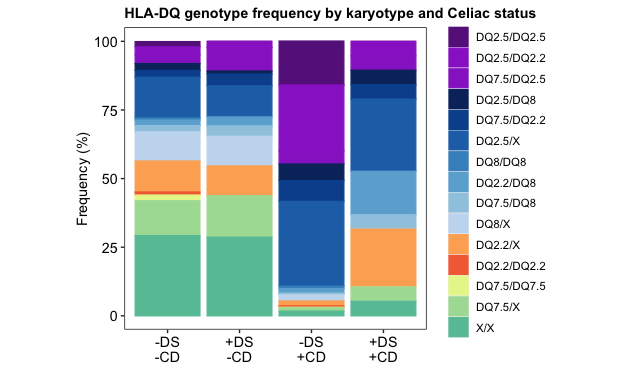

```r
# Setting and modifying theme for plots
theme_set(theme_gray(base_size = 12, base_family = "Arial") +
            theme(panel.border = element_rect(colour="black", fill = "transparent"),
                  plot.title = element_text(face="bold", hjust = 0, size = 12), # lineheight=.8, size=20,
                  axis.text = element_text(color="black", size = 12),
                  axis.text.x = element_text(angle = 0, hjust = NULL),
                  strip.background = element_rect(colour="black", fill = "light grey", size = 1), # adjusts facet label borders (if any)
                  panel.background = element_blank(),
                  panel.grid = element_blank()
          ))

purples <- brewer.pal(n = 9, name = "BuPu")[c(6,8,9)] %>% rev()
deeppinks <- c("deeppink4", "deeppink3", "deeppink2")
darkorchids <- c("darkorchid4", "darkorchid3", "darkorchid")
blues <- brewer.pal(n = 9, name = "Blues")[3:9] %>% rev()
oranges <- brewer.pal(n = 11, name = "Spectral")[3:4] %>% rev()
greens <- brewer.pal(n = 11, name = "Spectral")[7:9]
option6 <- c(darkorchids, blues, oranges, greens)

plotData.HLADQ_freq.GRS2019 %>%
  #mutate(Group = gsub(" ", "\n", Group)) %>%
  ggplot(aes(x = Group, y = `Frequency (%)`, color = `HLA-DQ genotype`, fill = `HLA-DQ genotype`)) +
  geom_bar(position = "stack", stat = "identity") +
  xlab("") +
  ylab("Frequency (%)") +
  theme(legend.title = element_blank(),
        aspect.ratio = 1) +
  scale_colour_manual(values = option6) +
  scale_fill_manual(values = option6) +
  ggtitle("HLA-DQ genotype frequency by karyotype and Celiac status")
```

```r
setwd(dir.Figures)
```

```
Error in setwd(dir.Figures) : cannot change working directory
```

#### Make stacked barplot of HLA-DQ genotype frequencies

```r
purples <- brewer.pal(n = 9, name = "BuPu")[c(6,8,9)] %>% rev()
deeppinks <- c("deeppink4", "deeppink3", "deeppink2")
darkorchids <- c("darkorchid4", "darkorchid3", "darkorchid")
blues <- brewer.pal(n = 9, name = "Blues")[3:9] %>% rev()
oranges <- brewer.pal(n = 11, name = "Spectral")[3:4] %>% rev()
greens <- brewer.pal(n = 11, name = "Spectral")[7:9]
option6 <- c(darkorchids, blues, oranges, greens)
```

#### Red/Blue option

```r
# Setting and modifying theme for plots
theme_set(theme_gray(base_size = 12, base_family = "Arial") +
            theme(panel.border = element_rect(colour="black", fill = "transparent"),
                  plot.title = element_text(face="bold", hjust = 0, size = 12), # lineheight=.8, size=20,
                  axis.text = element_text(color="black", size = 12),
                  axis.text.x = element_text(angle = 0, hjust = NULL),
                  strip.background = element_rect(colour="black", fill = "light grey", size = 1), # adjusts facet label borders (if any)
                  panel.background = element_blank(),
                  panel.grid = element_blank()
          ))

# # Pretty good:
# rev(colfunc.Reds(12)) %>% tail(n=12)
# colfunc.Reds <- colorRampPalette(c(brewer.pal(n = 9, name = "Reds")[1],
#                                    brewer.pal(n=9, name = "Reds")[8]))
# colfunc.Blues <- colorRampPalette(c("white", "#08519C"))
# custom.RedBlue1 <- c( rev(colfunc.Reds(15)[15]),
#                      rev(colfunc.Reds(15)[2:13]),
#                      colfunc.Blues(6) %>% tail(n=3) )
# custom.RedBlue2 <- c( rev(colfunc.Reds(15)[15]),
#                      rev(colfunc.Reds(15) %>% tail(n=11)),
#                      colfunc.Blues(6) %>% tail(n=3) )
# custom.RedBlue3 <- c( rev(colfunc.Reds(15)[15]),
#                      rev(colfunc.Reds(15)[1:12]),
#                      colfunc.Blues(6) %>% tail(n=3) )
# custom.RedBlue4 <- c( rev(colfunc.Reds(15)[15]),
#                      rev(colfunc.Reds(15)[3:14]),
#                      colfunc.Blues(6) %>% tail(n=3) )

# colfunc.RdOr <- colorRampPalette(c(brewer.pal(n = 9, name = "OrRd")[3],
#                                    brewer.pal(n=9, name = "Reds")[7]))
# colfunc.Blues <- colorRampPalette(c("white", "#08519C"))
# colfunc.Reds <- colorRampPalette(c(brewer.pal(n = 9, name = "Reds")[1],
#                                    brewer.pal(n=9, name = "Reds")[8]))
# custom.RdOrBlue <- c( rev(colfunc.Reds(15)[15]),
#                       rev(colfunc.RdOr(12)) %>% tail(n=11),
#                      colfunc.Blues(6) %>% tail(n=3) )
# custom.RedBlue <- c( rev(colfunc.Reds(15)[15]),
#                      rev(colfunc.Reds(15)[2:13]),
#                      colfunc.Blues(6) %>% tail(n=3) )

# plotData.HLADQ_freq %>%
#   mutate(Permissive = ifelse(grepl("Non-permissive", Genotype_category)==TRUE, 0, 1),
#          Permissive = factor(Permissive, levels = c(0,1)),
#          Genotype_category = factor(Genotype_category,
#                                     levels = c("Non-permissive", "Permissive, low risk", "Permissive, intermediate risk", "Permissive, high risk")),
#          Genotype_category.num = as.numeric(Genotype_category)) %>%
#   mutate(Group = gsub(" ", "\n", Group)) %>%
#   ggplot(aes(x = Group, y = `Frequency (%)`, color = `HLA-DQ genotype`, fill = `HLA-DQ genotype`)) +
#   geom_bar(position = "stack", stat = "identity") +
#   xlab("") +
#   ylab("Frequency (%)") +
#   theme(legend.title = element_blank(),
#         aspect.ratio = 1) +
#   scale_colour_manual(values = custom.RedBlue1) +
#   scale_fill_manual(values = custom.RedBlue1) +
#   ggtitle("HLA-DQ genotype frequency by karyotype and Celiac status") # +

# plotData.HLADQ_freq %>%
#   mutate(Permissive = ifelse(grepl("Non-permissive", Genotype_category)==TRUE, 0, 1),
#          Permissive = factor(Permissive, levels = c(0,1)),
#          Genotype_category = factor(Genotype_category,
#                                     levels = c("Non-permissive", "Permissive, low risk", "Permissive, intermediate risk", "Permissive, high risk")),
#          Genotype_category.num = as.numeric(Genotype_category)) %>%
#   mutate(Group = gsub(" ", "\n", Group)) %>%
#   ggplot(aes(x = Group, y = `Frequency (%)`, color = `HLA-DQ genotype`, fill = `HLA-DQ genotype`)) +
#   geom_bar(position = "stack", stat = "identity") +
#   xlab("") +
#   ylab("Frequency (%)") +
#   theme(legend.title = element_blank(),
#         aspect.ratio = 1) +
#   scale_colour_manual(values = custom.RedBlue3) +
#   scale_fill_manual(values = custom.RedBlue3) +
#   ggtitle("HLA-DQ genotype frequency by karyotype and Celiac status") # +

# plotData.HLADQ_freq %>%
#   mutate(Permissive = ifelse(grepl("Non-permissive", Genotype_category)==TRUE, 0, 1),
#          Permissive = factor(Permissive, levels = c(0,1)),
#          Genotype_category = factor(Genotype_category,
#                                     levels = c("Non-permissive", "Permissive, low risk", "Permissive, intermediate risk", "Permissive, high risk")),
#          Genotype_category.num = as.numeric(Genotype_category)) %>%
#   mutate(Group = gsub(" ", "\n", Group)) %>%
#   ggplot(aes(x = Group, y = `Frequency (%)`, color = `HLA-DQ genotype`, fill = `HLA-DQ genotype`)) +
#   geom_bar(position = "stack", stat = "identity") +
#   xlab("") +
#   ylab("Frequency (%)") +
#   theme(legend.title = element_blank(),
#         aspect.ratio = 1) +
#   scale_colour_manual(values = custom.RedBlue4) +
#   scale_fill_manual(values = custom.RedBlue4) +
#   ggtitle("HLA-DQ genotype frequency by karyotype and Celiac status") # +

colfunc.RdOr <- colorRampPalette(c(brewer.pal(n = 9, name = "OrRd")[3],
                                   brewer.pal(n=9, name = "Reds")[7]))
colfunc.Blues <- colorRampPalette(c("white", "#08519C"))
colfunc.Reds <- colorRampPalette(c(brewer.pal(n = 9, name = "Reds")[1],
                                   brewer.pal(n=9, name = "Reds")[8]))
custom.RedBlue3 <- c( rev(colfunc.Reds(15)[15]),
                     rev(colfunc.Reds(15)[2:12]),
                     colfunc.Blues(6) %>% tail(n=3) )
length(custom.RedBlue3)
stacked.DQfreq.RedBlue <- plotData.HLADQ_freq %>%
  # mutate(Permissive = ifelse(grepl("Non-permissive", Genotype_category)==TRUE, 0, 1),
  #        Permissive = factor(Permissive, levels = c(0,1)),
  #        Genotype_category = factor(Genotype_category,
  #                                   levels = c("Non-permissive", "Permissive, low risk", "Permissive, intermediate risk", "Permissive, high risk")),
  #        Genotype_category.num = as.numeric(Genotype_category)) %>%
  # mutate(Group = gsub(" ", "\n", Group),
  #        Group = factor(Group, levels = c("-DS\n+CD", "+DS\n+CD", "-DS\n-CD", "+DS\n-CD"))) %>%
  ggplot(aes(x = Group, y = `Frequency (%)`, color = `HLA-DQ genotype`, fill = `HLA-DQ genotype`)) +
  geom_bar(position = "stack", stat = "identity") +
  xlab("") +
  ylab("Frequency (%)") +
  theme(legend.title = element_blank(),
        aspect.ratio = 1) +
  scale_colour_manual(values = custom.RedBlue3) +
  scale_fill_manual(values = custom.RedBlue3) +
  ggtitle("HLA-DQ genotype frequency by karyotype and Celiac status") # +

stacked.DQfreq.RedBlue

setwd(dir.Figures)
filename <- "MEGA_022322_StackedBarplot_HLADQ_Genotype_Frequencies_RedBlue_v0.1_JRS"
ggsave(stacked.DQfreq.RedBlue,
       filename = paste(filename, ".png", sep = ""),
       width = 7, height = 5, units = "in")
ggsave(stacked.DQfreq.RedBlue,
       filename = paste(filename, ".pdf", sep = ""),
       device = cairo_pdf, width = 7, height = 5, units = "in")
```

#### Red/Orange/Blue option

```r
theme_set(theme_gray(base_size = 12, base_family = "Arial") +
            theme(panel.border = element_rect(colour="black", fill = "transparent"),
                  plot.title = element_text(face="bold", hjust = 0, size = 12), # lineheight=.8, size=20,
                  axis.text = element_text(color="black", size = 12),
                  axis.text.x = element_text(angle = 0, hjust = NULL),
                  strip.background = element_rect(colour="black", fill = "light grey", size = 1), # adjusts facet label borders (if any)
                  panel.background = element_blank(),
                  panel.grid = element_blank()
          ))
# brewer.pal(n = 12, name = "OrRd")
# display.brewer.pal(n=9, name = "OrRd")
# rev(colfunc.Reds(12)) %>% tail(n=12)
# brewer.pal(n = 12, name = "OrRd")
custom.RedBlue3 <- c( rev(colfunc.Reds(15)[15]),
                     rev(colfunc.Reds(15)[2:12]),
                     colfunc.Blues(6) %>% tail(n=3) )
colfunc.RdOr <- colorRampPalette(c(brewer.pal(n = 9, name = "OrRd")[3],
                                   brewer.pal(n=9, name = "Reds")[7]))
colfunc.Blues <- colorRampPalette(c("white", "#08519C"))
colfunc.Reds <- colorRampPalette(c(brewer.pal(n = 9, name = "Reds")[1],
                                   brewer.pal(n=9, name = "Reds")[8]))
custom.RdOrBlue <- c( rev(colfunc.Reds(15)[15]),
                      rev(colfunc.RdOr(12)) %>% tail(n=11),
                     colfunc.Blues(6) %>% tail(n=3) )
custom.RedBlue <- c( rev(colfunc.Reds(15)[15]),
                     rev(colfunc.Reds(15)[2:12]),
                     colfunc.Blues(6) %>% tail(n=3) )
length(custom.RedBlue)
stacked.DQfreq.RedOrBlue <- plotData.HLADQ_freq %>%
  # mutate(Permissive = ifelse(grepl("Non-permissive", Genotype_category)==TRUE, 0, 1),
  #        Permissive = factor(Permissive, levels = c(0,1)),
  #        Genotype_category = factor(Genotype_category,
  #                                   levels = c("Non-permissive", "Permissive, low risk", "Permissive, intermediate risk", "Permissive, high risk")),
  #        Genotype_category.num = as.numeric(Genotype_category)) %>%
  # mutate(Group = gsub(" ", "\n", Group),
  #        Group = factor(Group, levels = c("-DS\n+CD", "+DS\n+CD", "-DS\n-CD", "+DS\n-CD"))) %>%
  ggplot(aes(x = Group, y = `Frequency (%)`, color = `HLA-DQ genotype`, fill = `HLA-DQ genotype`)) +
  geom_bar(position = "stack", stat = "identity") +
  xlab("") +
  ylab("Frequency (%)") +
  theme(legend.title = element_blank(),
        aspect.ratio = 1) +
  scale_colour_manual(values = custom.RdOrBlue) +
  scale_fill_manual(values = custom.RdOrBlue) +
  ggtitle("HLA-DQ genotype frequency by karyotype and Celiac status") # +

stacked.DQfreq.RedOrBlue

setwd(dir.Figures)
filename <- "MEGA_022322_StackedBarplot_HLADQ_Genotype_Frequencies_RedOrangeBlue_v0.1_JRS"
ggsave(stacked.DQfreq.RedOrBlue,
       filename = paste(filename, ".png", sep = ""),
       width = 7, height = 5, units = "in")
ggsave(stacked.DQfreq.RedOrBlue,
       filename = paste(filename, ".pdf", sep = ""),
       device = cairo_pdf, width = 7, height = 5, units = "in")
```

```r
# plotData.HLADQ_freq %>%
#   select(-Genotype_category) %>%
#   arrange(Group) %>%
#   group_by(Group) %>%
#   summarise(sum(`Frequency (%)`))

DQfreq.T21minusD21.RedBlue <- plotData.HLADQ_freq %>%
  select(-Genotype_category) %>%
  select(`HLA-DQ genotype`, Group, `Frequency (%)`) %>%
  separate(Group, into = c("Karyotype", "Celiac"), sep = "\n", extra = "merge", remove = FALSE) %>%
  select(`HLA-DQ genotype`, Karyotype, Celiac, `Frequency (%)`) %>%
  spread(key = Karyotype, value = `Frequency (%)`) %>%
  mutate(`delta_Frequency (T21 - D21)` = `+DS` - `-DS`) %>%
  arrange(`delta_Frequency (T21 - D21)`) %>%
  ggplot(aes(x = Celiac, y = `delta_Frequency (T21 - D21)`, color = `HLA-DQ genotype`, fill = `HLA-DQ genotype`)) +
  #geom_bar(position = "stack", stat = "identity") +
  geom_bar(position = "dodge", stat = "identity") +
  xlab("") +
  #ylab("delta_Frequency (%)") +
  #ylab(bquote('%'~Freq[T21]~'')) +  # -%[D21]~'')) +
  ylab(bquote(''~Freq[T21]-Freq[D21]~'')) +  # -%[D21]~'')) +
  #ylab( paste("test", bquote(''~Freq[T21]~''), sep = "") ) +  # -%[D21]~'')) +
  #ylab(bquote(''~-log[10](P)~'')) +
  theme(legend.title = element_blank(),
        aspect.ratio = 1) +
  scale_colour_manual(values = custom.RedBlue3) +
  scale_fill_manual(values = custom.RedBlue3) +
  ggtitle("HLA-DQ genotype frequencies by CD\nin T21 compared to D21*") +
  labs(caption = "*As reported in Sharp et al., 2019.") +
  geom_hline(yintercept = 0, color = "black")

DQfreq.T21minusD21.RedOrBlue <- plotData.HLADQ_freq %>%
  select(-Genotype_category) %>%
  select(`HLA-DQ genotype`, Group, `Frequency (%)`) %>%
  separate(Group, into = c("Karyotype", "Celiac"), sep = "\n", extra = "merge", remove = FALSE) %>%
  select(`HLA-DQ genotype`, Karyotype, Celiac, `Frequency (%)`) %>%
  spread(key = Karyotype, value = `Frequency (%)`) %>%
  mutate(`delta_Frequency (T21 - D21)` = `+DS` - `-DS`) %>%
  arrange(`delta_Frequency (T21 - D21)`) %>%
  ggplot(aes(x = Celiac, y = `delta_Frequency (T21 - D21)`, color = `HLA-DQ genotype`, fill = `HLA-DQ genotype`)) +
  #geom_bar(position = "stack", stat = "identity") +
  geom_bar(position = "dodge", stat = "identity") +
  xlab("") +
  #ylab("delta_Frequency (%)") +
  #ylab(bquote('%'~Freq[T21]~'')) +  # -%[D21]~'')) +
  ylab(bquote(''~Freq[T21]-Freq[D21]~'')) +  # -%[D21]~'')) +
  #ylab( paste("test", bquote(''~Freq[T21]~''), sep = "") ) +  # -%[D21]~'')) +
  #ylab(bquote(''~-log[10](P)~'')) +
  theme(legend.title = element_blank(),
        aspect.ratio = 1) +
  scale_colour_manual(values = custom.RdOrBlue) +
  scale_fill_manual(values = custom.RdOrBlue) +
  ggtitle("HLA-DQ genotype frequencies by CD\nin T21 compared to D21*") +
  labs(caption = "*As reported in Sharp et al., 2019.") +
  geom_hline(yintercept = 0, color = "black")

DQfreq.T21minusD21.RedBlue
DQfreq.T21minusD21.RedOrBlue

setwd(dir.Figures)
filename <- "MEGA_022322_Barplot_HLADQfreq_T21vsD21_RedBlue_v0.1_JRS"
ggsave(DQfreq.T21minusD21.RedBlue,
       filename = paste(filename, ".png", sep = ""),
       width = 7, height = 5, units = "in")
ggsave(DQfreq.T21minusD21.RedBlue,
       filename = paste(filename, ".pdf", sep = ""),
       device = cairo_pdf, width = 7, height = 5, units = "in")

setwd(dir.Figures)
filename <- "MEGA_022322_Barplot_HLADQfreq_T21vsD21_RedOrangeBlue_v0.1_JRS"
ggsave(DQfreq.T21minusD21.RedOrBlue,
       filename = paste(filename, ".png", sep = ""),
       width = 7, height = 5, units = "in")
ggsave(DQfreq.T21minusD21.RedOrBlue,
       filename = paste(filename, ".pdf", sep = ""),
       device = cairo_pdf, width = 7, height = 5, units = "in")
```

#### Make another set of tables to summarize frequencies of HLA-DQ genotypes grouped by Celiac-permissive vs. non-permissive

```r
HLADQ_freq.PermissiveVsNonPermissive.long <- plotData.HLADQ_freq %>%
  mutate(Category = ifelse(Genotype_category=="Non-permissive", "Non-permissive", "Permissive")) %>%
  group_by(Category, Group) %>%
  summarise(`Frequency (%)` = round(sum(`Frequency (%)`), digits = 1)) %>%
  ungroup() %>%
  select(Group, Category, `Frequency (%)`) %>%
  rename(`HLA-DQ genotype category` = Category) %>%
  mutate(Group = gsub("\n", " ", Group))

HLADQ_freq.PermissiveVsNonPermissive.wide <- HLADQ_freq.PermissiveVsNonPermissive.long %>%
  spread(key = `HLA-DQ genotype category`, value = `Frequency (%)`) %>%
  mutate(Total = round(`Non-permissive` + Permissive, digits = 0)) %>%
  rename(`Non-permissive HLA-DQ genotype (%)` = `Non-permissive`,
         `Permissive HLA-DQ genotype (%)` = Permissive,
         `Total (%)` = Total)

HLADQ_freq.PermissiveVsNonPermissive.long
HLADQ_freq.PermissiveVsNonPermissive.wide

setwd(dir.Tables)
fwrite(HLADQ_freq.PermissiveVsNonPermissive.long %>%
         # Add a space before the group abbreviations to prevent errors when opening in Excel:
         mutate(Group = paste(" ", Group, " ", sep = "")),
       "MEGA_022322_HLADQgenotype_PermissiveVsNon_FreqByCDandDS_LONG_v0.1_JRS.csv")
fwrite(HLADQ_freq.PermissiveVsNonPermissive.wide %>%
         # Add a space before the group abbreviations to prevent errors when opening in Excel:
         mutate(Group = paste(" ", Group, " ", sep = "")),
       "MEGA_022322_HLADQgenotype_PermissiveVsNon_FreqByCDandDS_WIDE_v0.1_JRS.csv")

setwd(dir.Tables)
fwrite(HLADQ_freq.PermissiveVsNonPermissive.long, "MEGA_022322_HLADQgenotype_PermissiveVsNon_FreqByCDandDS_LONG_v0.1_JRS.tsv", sep = "\t")
fwrite(HLADQ_freq.PermissiveVsNonPermissive.wide, "MEGA_022322_HLADQgenotype_PermissiveVsNon_FreqByCDandDS_WIDE_v0.1_JRS.tsv", sep = "\t")
```

```r
stacked.DQfreq.RedBlue.facetByDS <- plotData.HLADQ_freq %>%
  separate(Group, into = c("DS", "CD"), sep = "\n", extra = "merge", remove = FALSE) %>%
  # mutate(Permissive = ifelse(grepl("Non-permissive", Genotype_category)==TRUE, 0, 1),
  #        Permissive = factor(Permissive, levels = c(0,1)),
  #        Genotype_category = factor(Genotype_category,
  #                                   levels = c("Non-permissive", "Permissive, low risk", "Permissive, intermediate risk", "Permissive, high risk")),
  #        Genotype_category.num = as.numeric(Genotype_category)) %>%
  # mutate(Group = gsub(" ", "\n", Group),
  #        Group = factor(Group, levels = c("-DS\n+CD", "+DS\n+CD", "-DS\n-CD", "+DS\n-CD"))) %>%
  ggplot(aes(x = CD, y = `Frequency (%)`, color = `HLA-DQ genotype`, fill = `HLA-DQ genotype`)) +
  geom_bar(position = "stack", stat = "identity") +
  xlab("") +
  ylab("Frequency (%)") +
  theme(legend.title = element_blank(),
        aspect.ratio = 1) +
  scale_colour_manual(values = custom.RedBlue3) +
  scale_fill_manual(values = custom.RedBlue3) +
  facet_wrap(~DS)
  ggtitle("HLA-DQ genotype frequency by karyotype and Celiac status") # +

stacked.DQfreq.RedBlue.facetByDS

setwd(dir.Figures)
filename <- "MEGA_022322_StackedBarplot_HLADQ_Genotype_Frequencies_RedBlue_FacetByDS_v0.1_JRS"
ggsave(stacked.DQfreq.RedBlue.facetByDS,
       filename = paste(filename, ".png", sep = ""),
       width = 7, height = 5, units = "in")
ggsave(stacked.DQfreq.RedBlue.facetByDS,
       filename = paste(filename, ".pdf", sep = ""),
       device = cairo_pdf, width = 7, height = 5, units = "in")

stacked.DQfreq.RedBlue.facetByCD <- plotData.HLADQ_freq %>%
  separate(Group, into = c("DS", "CD"), sep = "\n", extra = "merge", remove = FALSE) %>%
  # mutate(Permissive = ifelse(grepl("Non-permissive", Genotype_category)==TRUE, 0, 1),
  #        Permissive = factor(Permissive, levels = c(0,1)),
  #        Genotype_category = factor(Genotype_category,
  #                                   levels = c("Non-permissive", "Permissive, low risk", "Permissive, intermediate risk", "Permissive, high risk")),
  #        Genotype_category.num = as.numeric(Genotype_category)) %>%
  # mutate(Group = gsub(" ", "\n", Group),
  #        Group = factor(Group, levels = c("-DS\n+CD", "+DS\n+CD", "-DS\n-CD", "+DS\n-CD"))) %>%
  ggplot(aes(x = DS, y = `Frequency (%)`, color = `HLA-DQ genotype`, fill = `HLA-DQ genotype`)) +
  geom_bar(position = "stack", stat = "identity") +
  xlab("") +
  ylab("Frequency (%)") +
  theme(legend.title = element_blank(),
        aspect.ratio = 1) +
  scale_colour_manual(values = custom.RedBlue3) +
  scale_fill_manual(values = custom.RedBlue3) +
  facet_wrap(~CD)
  ggtitle("HLA-DQ genotype frequency by karyotype and Celiac status") # +

stacked.DQfreq.RedBlue.facetByCD

setwd(dir.Figures)
filename <- "MEGA_022322_StackedBarplot_HLADQ_Genotype_Frequencies_RedBlue_FacetByCD_v0.1_JRS"
ggsave(stacked.DQfreq.RedBlue.facetByCD,
       filename = paste(filename, ".png", sep = ""),
       width = 7, height = 5, units = "in")
ggsave(stacked.DQfreq.RedBlue.facetByCD,
       filename = paste(filename, ".pdf", sep = ""),
       device = cairo_pdf, width = 7, height = 5, units = "in")
```

```r
# High = red
# Orange? Yellow?
# Green
# Non-permissive = blue
# OR
# High = red
# Orange? Yellow?/Green = combined low/intermediate risk
# Non-permissive = blue

# ColorCat3.option1 = red/orange/blue
# ColorCat3.option2 = red/green/blue
# ColorCat4.option1 = red/orange/green/blue
# ColorCat4.option2 = red/gold/green/blue

plotData.HLADQ_freq.colorCat <- plotData.HLADQ_freq %>%
  mutate(
    # ColorCat4.option1 = red/orange/green/blue
    ColorCat4.option1 = ifelse(grepl("high", Genotype_category)==TRUE, "red",
                               ifelse(grepl("intermediate", Genotype_category)==TRUE, "orange",
                                      ifelse(grepl("low", Genotype_category)==TRUE, "green",
                                             ifelse(grepl("Non-permissive", Genotype_category)==TRUE, "blue", NA)))),
    # ColorCat4.option2 = red/gold/green/blue
    ColorCat4.option2 = ifelse(grepl("high", Genotype_category)==TRUE, "red",
                               ifelse(grepl("intermediate", Genotype_category)==TRUE, "gold",
                                      ifelse(grepl("low", Genotype_category)==TRUE, "green",
                                             ifelse(grepl("Non-permissive", Genotype_category)==TRUE, "blue", NA)))),
    # ColorCat3.option1 = red/orange/blue
    ColorCat3.option1 = ifelse(grepl("high", Genotype_category)==TRUE, "red",
                               ifelse(grepl("intermediate", Genotype_category)==TRUE | grepl("low", Genotype_category)==TRUE, "orange",
                                      ifelse(grepl("Non-permissive", Genotype_category)==TRUE, "blue", NA))),
    # ColorCat3.option2 = red/green/blue
    ColorCat3.option2 = ifelse(grepl("high", Genotype_category)==TRUE, "red",
                               ifelse(grepl("intermediate", Genotype_category)==TRUE | grepl("low", Genotype_category)==TRUE, "green",
                                      ifelse(grepl("Non-permissive", Genotype_category)==TRUE, "blue", NA)))
    )

plotData.HLADQ_freq.colorCat

plotData.HLADQ_freq.colorCat %>%
  select(`HLA-DQ genotype`, ColorCat4.option1) %>%
  unique() %>%
  group_by(ColorCat4.option1) %>%
  summarise(N = n())
plotData.HLADQ_freq.colorCat %>%
  select(`HLA-DQ genotype`, ColorCat4.option2) %>%
  unique() %>%
  group_by(ColorCat4.option2) %>%
  summarise(N = n())
plotData.HLADQ_freq.colorCat %>%
  select(`HLA-DQ genotype`, ColorCat3.option1) %>%
  unique() %>%
  group_by(ColorCat3.option1) %>%
  summarise(N = n())
plotData.HLADQ_freq.colorCat %>%
  select(`HLA-DQ genotype`, ColorCat3.option2) %>%
  unique() %>%
  group_by(ColorCat3.option2) %>%
  summarise(N = n())

# 2-color green scale
# 3-color blue scale
# 3-color red scale
# 7-color orange scale
# 7-color gold scale
# 9-color green scale
# 9-color orange scale
# 9-color gold scale
```

#### 3-color options

```r
# KEEP
# ColorCat3.option1 = red3/orange9/blue3
reds3.a <- brewer.pal(n = 8, name = "Reds")[6:8] %>% rev()
blues3.b <- brewer.pal(n = 9, name = "Blues")[5:7]
colfunc.orange9a <- colorRampPalette(c(brewer.pal(n = 9, name = "Oranges")[6],
                                   brewer.pal(n = 9, name = "Oranges")[2]))
custom.orange9a <- c( rev(colfunc.orange9a(9)) ) %>% rev()
pal.ColorCat3.Option1a <- c(reds3.a, custom.orange9a, blues3.b)
stacked.DQfreq.facetByCD.ColorCat3.Option1a <- plotData.HLADQ_freq %>%
  separate(Group, into = c("DS", "CD"), sep = "\n", extra = "merge", remove = FALSE) %>%
  ggplot(aes(x = DS, y = `Frequency (%)`, color = `HLA-DQ genotype`, fill = `HLA-DQ genotype`)) +
  geom_bar(position = "stack", stat = "identity") +
  xlab("") +
  ylab("Frequency (%)") +
  theme(legend.title = element_blank(),
        aspect.ratio = 1) +
  scale_colour_manual(values = pal.ColorCat3.Option1a) +
  scale_fill_manual(values = pal.ColorCat3.Option1a) +
  facet_wrap(~CD) +
  ggtitle("HLA-DQ genotype frequency by karyotype and Celiac status")
stacked.DQfreq.facetByCD.ColorCat3.Option1a

# KEEP
# ColorCat3.option1 = red3/orange9/blue3
reds3.a <- brewer.pal(n = 8, name = "Reds")[6:8] %>% rev()
blues3.b <- brewer.pal(n = 9, name = "Blues")[5:7]
colfunc.orange9a <- colorRampPalette(c(brewer.pal(n = 9, name = "Oranges")[5],
                                   brewer.pal(n = 9, name = "Oranges")[2]))
custom.orange9a <- c( rev(colfunc.orange9a(9)) ) %>% rev()
pal.ColorCat3.Option1b <- c(reds3.a, custom.orange9a, blues3.b)
stacked.DQfreq.facetByCD.ColorCat3.Option1b <- plotData.HLADQ_freq %>%
  separate(Group, into = c("DS", "CD"), sep = "\n", extra = "merge", remove = FALSE) %>%
  ggplot(aes(x = DS, y = `Frequency (%)`, color = `HLA-DQ genotype`, fill = `HLA-DQ genotype`)) +
  geom_bar(position = "stack", stat = "identity") +
  xlab("") +
  ylab("Frequency (%)") +
  theme(legend.title = element_blank(),
        aspect.ratio = 1) +
  scale_colour_manual(values = pal.ColorCat3.Option1b) +
  scale_fill_manual(values = pal.ColorCat3.Option1b) +
  facet_wrap(~CD) +
  ggtitle("HLA-DQ genotype frequency by karyotype and Celiac status")
stacked.DQfreq.facetByCD.ColorCat3.Option1b

# KEEP
# ColorCat3.option2 = red/gold/blue
reds3.a <- brewer.pal(n = 8, name = "Reds")[6:8] %>% rev()
blues3.b <- brewer.pal(n = 9, name = "Blues")[5:7]
colfunc.gold9 <- colorRampPalette(c(brewer.pal(n = 9, name = "Set3")[6], brewer.pal(n = 9, name = "YlOrRd")[2]))
custom.gold9 <- c( rev(colfunc.gold9(9)) ) %>% rev()
pal.ColorCat3.Option2 <- c(reds3.a, custom.gold9, blues3.b)
stacked.DQfreq.facetByCD.ColorCat3.Option2 <- plotData.HLADQ_freq %>%
  separate(Group, into = c("DS", "CD"), sep = "\n", extra = "merge", remove = FALSE) %>%
  ggplot(aes(x = DS, y = `Frequency (%)`, color = `HLA-DQ genotype`, fill = `HLA-DQ genotype`)) +
  geom_bar(position = "stack", stat = "identity") +
  xlab("") +
  ylab("Frequency (%)") +
  theme(legend.title = element_blank(),
        aspect.ratio = 1) +
  scale_colour_manual(values = pal.ColorCat3.Option2) +
  scale_fill_manual(values = pal.ColorCat3.Option2) +
  facet_wrap(~CD) +
  ggtitle("HLA-DQ genotype frequency by karyotype and Celiac status")
stacked.DQfreq.facetByCD.ColorCat3.Option2

# KEEP
# ColorCat3.option3 = red/green/blue
reds3.a <- brewer.pal(n = 8, name = "Reds")[6:8] %>% rev()
blues3.b <- brewer.pal(n = 9, name = "Blues")[6:8]
colfunc.green9 <- colorRampPalette(c(brewer.pal(n = 9, name = "Greens")[6],
                                   brewer.pal(n = 9, name = "Greens")[2]))
custom.green9 <- c( rev(colfunc.green9(9)) ) %>% rev()
pal.ColorCat3.Option3 <- c(reds3.a, custom.green9, blues3.b)
stacked.DQfreq.facetByCD.ColorCat3.Option3 <- plotData.HLADQ_freq %>%
  separate(Group, into = c("DS", "CD"), sep = "\n", extra = "merge", remove = FALSE) %>%
  ggplot(aes(x = DS, y = `Frequency (%)`, color = `HLA-DQ genotype`, fill = `HLA-DQ genotype`)) +
  geom_bar(position = "stack", stat = "identity") +
  xlab("") +
  ylab("Frequency (%)") +
  theme(legend.title = element_blank(),
        aspect.ratio = 1) +
  scale_colour_manual(values = pal.ColorCat3.Option3) +
  scale_fill_manual(values = pal.ColorCat3.Option3) +
  facet_wrap(~CD) +
  ggtitle("HLA-DQ genotype frequency by karyotype and Celiac status")
stacked.DQfreq.facetByCD.ColorCat3.Option3

reds3.a <- brewer.pal(n = 8, name = "Reds")[6:8] %>% rev()
blues3.b <- brewer.pal(n = 9, name = "Blues")[6:8]
colfunc.orange9a <- colorRampPalette(c(brewer.pal(n = 9, name = "Oranges")[6],
                                   brewer.pal(n = 9, name = "Oranges")[2]))
custom.orange9a <- c( rev(colfunc.orange9a(9)) ) %>% rev()
pal.ColorCat3.Option1c <- c(reds3.a, custom.orange9a, blues3.b)
stacked.DQfreq.facetByCD.ColorCat3.Option1c <- plotData.HLADQ_freq %>%
  separate(Group, into = c("DS", "CD"), sep = "\n", extra = "merge", remove = FALSE) %>%
  ggplot(aes(x = DS, y = `Frequency (%)`, color = `HLA-DQ genotype`, fill = `HLA-DQ genotype`)) +
  geom_bar(position = "stack", stat = "identity") +
  xlab("") +
  ylab("Frequency (%)") +
  theme(legend.title = element_blank(),
        aspect.ratio = 1) +
  scale_colour_manual(values = pal.ColorCat3.Option1c) +
  scale_fill_manual(values = pal.ColorCat3.Option1c) +
  facet_wrap(~CD) +
  ggtitle("HLA-DQ genotype frequency by karyotype and Celiac status")
stacked.DQfreq.facetByCD.ColorCat3.Option1c

reds3.a <- brewer.pal(n = 8, name = "Reds")[6:8] %>% rev()
blues3.b <- brewer.pal(n = 9, name = "Blues")[6:8]
colfunc.orange9a <- colorRampPalette(c(brewer.pal(n = 9, name = "Oranges")[5],
                                   brewer.pal(n = 9, name = "Oranges")[2]))
custom.orange9a <- c( rev(colfunc.orange9a(9)) ) %>% rev()
pal.ColorCat3.Option1d <- c(reds3.a, custom.orange9a, blues3.b)
stacked.DQfreq.facetByCD.ColorCat3.Option1d <- plotData.HLADQ_freq %>%
  separate(Group, into = c("DS", "CD"), sep = "\n", extra = "merge", remove = FALSE) %>%
  ggplot(aes(x = DS, y = `Frequency (%)`, color = `HLA-DQ genotype`, fill = `HLA-DQ genotype`)) +
  geom_bar(position = "stack", stat = "identity") +
  xlab("") +
  ylab("Frequency (%)") +
  theme(legend.title = element_blank(),
        aspect.ratio = 1) +
  scale_colour_manual(values = pal.ColorCat3.Option1d) +
  scale_fill_manual(values = pal.ColorCat3.Option1d) +
  facet_wrap(~CD) +
  ggtitle("HLA-DQ genotype frequency by karyotype and Celiac status")
stacked.DQfreq.facetByCD.ColorCat3.Option1d
```

#### 4-color options

```r
# ColorCat4.option1 = red/orange/green/blue
# ColorCat4.option2 = red/gold/green/blue

# KEEP
# ColorCat4.option1 = red3/orange7green2/blue3
reds3.a <- brewer.pal(n = 8, name = "Reds")[6:8] %>% rev()
blues3.b <- brewer.pal(n = 9, name = "Blues")[6:8]
greens2 <- brewer.pal(n = 9, name = "Greens")[6:7]
colfunc.orange7 <- colorRampPalette(c(brewer.pal(n = 9, name = "Oranges")[6],
                                   brewer.pal(n = 9, name = "Oranges")[3]))
custom.orange7 <- c( rev(colfunc.orange7(7)) ) %>% rev()
pal.ColorCat4.Option1a <- c(reds3.a, custom.orange7, greens2, blues3.b)
stacked.DQfreq.facetByCD.ColorCat4.Option1a <- plotData.HLADQ_freq %>%
  separate(Group, into = c("DS", "CD"), sep = "\n", extra = "merge", remove = FALSE) %>%
  ggplot(aes(x = DS, y = `Frequency (%)`, color = `HLA-DQ genotype`, fill = `HLA-DQ genotype`)) +
  geom_bar(position = "stack", stat = "identity") +
  xlab("") +
  ylab("Frequency (%)") +
  theme(legend.title = element_blank(),
        aspect.ratio = 1) +
  scale_colour_manual(values = pal.ColorCat4.Option1a) +
  scale_fill_manual(values = pal.ColorCat4.Option1a) +
  facet_wrap(~CD) +
  ggtitle("HLA-DQ genotype frequency by karyotype and Celiac status")
stacked.DQfreq.facetByCD.ColorCat4.Option1a

# KEEP
# ColorCat4.option1 = red3/orange7green2/blue3
reds3.a <- brewer.pal(n = 8, name = "Reds")[6:8] %>% rev()
blues3.b <- brewer.pal(n = 9, name = "Blues")[5:7]
greens2 <- brewer.pal(n = 9, name = "Greens")[6:7]
colfunc.orange7 <- colorRampPalette(c(brewer.pal(n = 9, name = "Oranges")[6],
                                   brewer.pal(n = 9, name = "Oranges")[3]))
custom.orange7 <- c( rev(colfunc.orange7(7)) ) %>% rev()
pal.ColorCat4.Option1b <- c(reds3.a, custom.orange7, greens2, blues3.b)
stacked.DQfreq.facetByCD.ColorCat4.Option1b <- plotData.HLADQ_freq %>%
  separate(Group, into = c("DS", "CD"), sep = "\n", extra = "merge", remove = FALSE) %>%
  ggplot(aes(x = DS, y = `Frequency (%)`, color = `HLA-DQ genotype`, fill = `HLA-DQ genotype`)) +
  geom_bar(position = "stack", stat = "identity") +
  xlab("") +
  ylab("Frequency (%)") +
  theme(legend.title = element_blank(),
        aspect.ratio = 1) +
  scale_colour_manual(values = pal.ColorCat4.Option1b) +
  scale_fill_manual(values = pal.ColorCat4.Option1b) +
  facet_wrap(~CD) +
  ggtitle("HLA-DQ genotype frequency by karyotype and Celiac status")
stacked.DQfreq.facetByCD.ColorCat4.Option1b

# ColorCat4.option2 = red/gold/green/blue
reds3.a <- brewer.pal(n = 8, name = "Reds")[6:8] %>% rev()
colfunc.gold7 <- colorRampPalette(c(brewer.pal(n = 9, name = "Set3")[6], brewer.pal(n = 9, name = "YlOrRd")[2]))
custom.gold7 <- c( rev(colfunc.gold9(7)) ) %>% rev()
blues3.b <- brewer.pal(n = 9, name = "Blues")[5:7]
greens2 <- brewer.pal(n = 9, name = "Greens")[6:7]
colfunc.orange7 <- colorRampPalette(c(brewer.pal(n = 9, name = "Oranges")[6],
                                   brewer.pal(n = 9, name = "Oranges")[3]))
custom.orange7 <- c( rev(colfunc.orange7(7)) ) %>% rev()
pal.ColorCat4.Option2a <- c(reds3.a, custom.gold7, greens2, blues3.b)
stacked.DQfreq.facetByCD.ColorCat4.Option2a <- plotData.HLADQ_freq %>%
  separate(Group, into = c("DS", "CD"), sep = "\n", extra = "merge", remove = FALSE) %>%
  ggplot(aes(x = DS, y = `Frequency (%)`, color = `HLA-DQ genotype`, fill = `HLA-DQ genotype`)) +
  geom_bar(position = "stack", stat = "identity") +
  xlab("") +
  ylab("Frequency (%)") +
  theme(legend.title = element_blank(),
        aspect.ratio = 1) +
  scale_colour_manual(values = pal.ColorCat4.Option2a) +
  scale_fill_manual(values = pal.ColorCat4.Option2a) +
  facet_wrap(~CD) +
  ggtitle("HLA-DQ genotype frequency by karyotype and Celiac status")
stacked.DQfreq.facetByCD.ColorCat4.Option2a

# ColorCat4.option2 = red/gold/green/blue
reds3.a <- brewer.pal(n = 8, name = "Reds")[6:8] %>% rev()
colfunc.gold7 <- colorRampPalette(c("goldenrod3", brewer.pal(n = 9, name = "YlOrRd")[2]))
custom.gold7 <- c( rev(colfunc.gold9(7)) ) %>% rev()
blues3.b <- brewer.pal(n = 9, name = "Blues")[5:7]
greens2 <- brewer.pal(n = 9, name = "Greens")[6:7]
colfunc.orange7 <- colorRampPalette(c(brewer.pal(n = 9, name = "Oranges")[6],
                                   brewer.pal(n = 9, name = "Oranges")[3]))
custom.orange7 <- c( rev(colfunc.orange7(7)) ) %>% rev()
pal.ColorCat4.Option2b <- c(reds3.a, custom.gold7, greens2, blues3.b)
stacked.DQfreq.facetByCD.ColorCat4.Option2b <- plotData.HLADQ_freq %>%
  separate(Group, into = c("DS", "CD"), sep = "\n", extra = "merge", remove = FALSE) %>%
  ggplot(aes(x = DS, y = `Frequency (%)`, color = `HLA-DQ genotype`, fill = `HLA-DQ genotype`)) +
  geom_bar(position = "stack", stat = "identity") +
  xlab("") +
  ylab("Frequency (%)") +
  theme(legend.title = element_blank(),
        aspect.ratio = 1) +
  scale_colour_manual(values = pal.ColorCat4.Option2b) +
  scale_fill_manual(values = pal.ColorCat4.Option2b) +
  facet_wrap(~CD) +
  ggtitle("HLA-DQ genotype frequency by karyotype and Celiac status")
stacked.DQfreq.facetByCD.ColorCat4.Option2b

reds3.a <- brewer.pal(n = 8, name = "Reds")[6:8] %>% rev()
colfunc.gold7 <- colorRampPalette(c("goldenrod2", brewer.pal(n = 9, name = "YlOrRd")[2]))
custom.gold7 <- c( rev(colfunc.gold9(7)) ) %>% rev()
blues3.b <- brewer.pal(n = 9, name = "Blues")[6:8]
greens2 <- brewer.pal(n = 9, name = "Greens")[6:7]
colfunc.orange7 <- colorRampPalette(c(brewer.pal(n = 9, name = "Oranges")[6],
                                   brewer.pal(n = 9, name = "Oranges")[3]))
custom.orange7 <- c( rev(colfunc.orange7(7)) ) %>% rev()
pal.ColorCat4.Option2c <- c(reds3.a, custom.gold7, greens2, blues3.b)
stacked.DQfreq.facetByCD.ColorCat4.Option2c <- plotData.HLADQ_freq %>%
  separate(Group, into = c("DS", "CD"), sep = "\n", extra = "merge", remove = FALSE) %>%
  ggplot(aes(x = DS, y = `Frequency (%)`, color = `HLA-DQ genotype`, fill = `HLA-DQ genotype`)) +
  geom_bar(position = "stack", stat = "identity") +
  xlab("") +
  ylab("Frequency (%)") +
  theme(legend.title = element_blank(),
        aspect.ratio = 1) +
  scale_colour_manual(values = pal.ColorCat4.Option2c) +
  scale_fill_manual(values = pal.ColorCat4.Option2c) +
  facet_wrap(~CD) +
  ggtitle("HLA-DQ genotype frequency by karyotype and Celiac status")
stacked.DQfreq.facetByCD.ColorCat4.Option2c


reds3.a <- brewer.pal(n = 8, name = "Reds")[6:8] %>% rev()
colfunc.gold7 <- colorRampPalette(c("goldenrod2", brewer.pal(n = 9, name = "YlOrRd")[2]))
custom.gold7 <- c( rev(colfunc.gold9(7)) ) %>% rev()
blues3.b <- brewer.pal(n = 9, name = "Blues")[6:8]
greens2 <- brewer.pal(n = 9, name = "Greens")[6:7]
colfunc.orange7 <- colorRampPalette(c(brewer.pal(n = 9, name = "Oranges")[6],
                                   brewer.pal(n = 9, name = "Oranges")[3]))
custom.orange7 <- c( rev(colfunc.orange7(7)) ) %>% rev()
colfunc.blue3 <- colorRampPalette(c(brewer.pal(n = 9, name = "Blues")[5],
                                   brewer.pal(n = 9, name = "Blues")[8]))
custom.blue3 <- c( rev(colfunc.blue3(3)) ) %>% rev()
pal.ColorCat4.Option2d <- c(reds3.a, custom.gold7, greens2, custom.blue3)
stacked.DQfreq.facetByCD.ColorCat4.Option2d <- plotData.HLADQ_freq %>%
  separate(Group, into = c("DS", "CD"), sep = "\n", extra = "merge", remove = FALSE) %>%
  ggplot(aes(x = DS, y = `Frequency (%)`, color = `HLA-DQ genotype`, fill = `HLA-DQ genotype`)) +
  geom_bar(position = "stack", stat = "identity") +
  xlab("") +
  ylab("Frequency (%)") +
  theme(legend.title = element_blank(),
        aspect.ratio = 1) +
  scale_colour_manual(values = pal.ColorCat4.Option2d) +
  scale_fill_manual(values = pal.ColorCat4.Option2d) +
  facet_wrap(~CD) +
  ggtitle("HLA-DQ genotype frequency by karyotype and Celiac status")
stacked.DQfreq.facetByCD.ColorCat4.Option2d
```

```r
stackedDQfreq.facetByCD.RdOrBu1 <- stacked.DQfreq.facetByCD.ColorCat3.Option1a
stackedDQfreq.facetByCD.RdOrBu2 <- stacked.DQfreq.facetByCD.ColorCat3.Option1b
stackedDQfreq.facetByCD.RdOrBu3 <- stacked.DQfreq.facetByCD.ColorCat3.Option1c
stackedDQfreq.facetByCD.RdOrBu4 <- stacked.DQfreq.facetByCD.ColorCat3.Option1d

stackedDQfreq.facetByCD.RdYlGnBu1 <- stacked.DQfreq.facetByCD.ColorCat4.Option2a
stackedDQfreq.facetByCD.RdYlGnBu2 <- stacked.DQfreq.facetByCD.ColorCat4.Option2b
stackedDQfreq.facetByCD.RdYlGnBu3 <- stacked.DQfreq.facetByCD.ColorCat4.Option2c
stackedDQfreq.facetByCD.RdYlGnBu4 <- stacked.DQfreq.facetByCD.ColorCat4.Option2d

stackedDQfreq.facetByCD.RdGnBu1 <- stacked.DQfreq.facetByCD.ColorCat3.Option3

setwd(dir.Figures)
filename <- "MEGA_022322_StackedBar_HLADQfreq_FacetByCD_RdOrBu1_v0.1_JRS"
ggsave(stackedDQfreq.facetByCD.RdOrBu1,
       filename = paste(filename, ".png", sep = ""),
       width = 7, height = 5, units = "in")
ggsave(stackedDQfreq.facetByCD.RdOrBu1,
       filename = paste(filename, ".pdf", sep = ""),
       device = cairo_pdf, width = 7, height = 5, units = "in")
setwd(dir.Figures)
filename <- "MEGA_022322_StackedBar_HLADQfreq_FacetByCD_RdOrBu2_v0.1_JRS"
ggsave(stackedDQfreq.facetByCD.RdOrBu2,
       filename = paste(filename, ".png", sep = ""),
       width = 7, height = 5, units = "in")
ggsave(stackedDQfreq.facetByCD.RdOrBu2,
       filename = paste(filename, ".pdf", sep = ""),
       device = cairo_pdf, width = 7, height = 5, units = "in")
setwd(dir.Figures)
filename <- "MEGA_022322_StackedBar_HLADQfreq_FacetByCD_RdOrBu3_v0.1_JRS"
ggsave(stackedDQfreq.facetByCD.RdOrBu3,
       filename = paste(filename, ".png", sep = ""),
       width = 7, height = 5, units = "in")
ggsave(stackedDQfreq.facetByCD.RdOrBu3,
       filename = paste(filename, ".pdf", sep = ""),
       device = cairo_pdf, width = 7, height = 5, units = "in")
setwd(dir.Figures)
filename <- "MEGA_022322_StackedBar_HLADQfreq_FacetByCD_RdOrBu4_v0.1_JRS"
ggsave(stackedDQfreq.facetByCD.RdOrBu4,
       filename = paste(filename, ".png", sep = ""),
       width = 7, height = 5, units = "in")
ggsave(stackedDQfreq.facetByCD.RdOrBu4,
       filename = paste(filename, ".pdf", sep = ""),
       device = cairo_pdf, width = 7, height = 5, units = "in")

setwd(dir.Figures)
filename <- "MEGA_022322_StackedBar_HLADQfreq_FacetByCD_RdYlGnBu1_v0.1_JRS"
ggsave(stackedDQfreq.facetByCD.RdYlGnBu1,
       filename = paste(filename, ".png", sep = ""),
       width = 7, height = 5, units = "in")
ggsave(stackedDQfreq.facetByCD.RdYlGnBu1,
       filename = paste(filename, ".pdf", sep = ""),
       device = cairo_pdf, width = 7, height = 5, units = "in")
setwd(dir.Figures)
filename <- "MEGA_022322_StackedBar_HLADQfreq_FacetByCD_RdYlGnBu2_v0.1_JRS"
ggsave(stackedDQfreq.facetByCD.RdYlGnBu2,
       filename = paste(filename, ".png", sep = ""),
       width = 7, height = 5, units = "in")
ggsave(stackedDQfreq.facetByCD.RdYlGnBu2,
       filename = paste(filename, ".pdf", sep = ""),
       device = cairo_pdf, width = 7, height = 5, units = "in")
setwd(dir.Figures)
filename <- "MEGA_022322_StackedBar_HLADQfreq_FacetByCD_RdYlGnBu3_v0.1_JRS"
ggsave(stackedDQfreq.facetByCD.RdYlGnBu3,
       filename = paste(filename, ".png", sep = ""),
       width = 7, height = 5, units = "in")
ggsave(stackedDQfreq.facetByCD.RdYlGnBu3,
       filename = paste(filename, ".pdf", sep = ""),
       device = cairo_pdf, width = 7, height = 5, units = "in")
setwd(dir.Figures)
filename <- "MEGA_022322_StackedBar_HLADQfreq_FacetByCD_RdYlGnBu4_v0.1_JRS"
ggsave(stackedDQfreq.facetByCD.RdYlGnBu4,
       filename = paste(filename, ".png", sep = ""),
       width = 7, height = 5, units = "in")
ggsave(stackedDQfreq.facetByCD.RdYlGnBu4,
       filename = paste(filename, ".pdf", sep = ""),
       device = cairo_pdf, width = 7, height = 5, units = "in")

setwd(dir.Figures)
filename <- "MEGA_022322_StackedBar_HLADQfreq_FacetByCD_RdGnBu1_v0.1_JRS"
ggsave(stackedDQfreq.facetByCD.RdGnBu1,
       filename = paste(filename, ".png", sep = ""),
       width = 7, height = 5, units = "in")
ggsave(stackedDQfreq.facetByCD.RdGnBu1,
       filename = paste(filename, ".pdf", sep = ""),
       device = cairo_pdf, width = 7, height = 5, units = "in")
```

```r
# -DS vs. +DS -> Sharp (D21) vs. HTP (T21)

reds3.a <- brewer.pal(n = 8, name = "Reds")[6:8] %>% rev()
colfunc.gold7 <- colorRampPalette(c("goldenrod3", brewer.pal(n = 9, name = "YlOrRd")[2]))
custom.gold7 <- c( rev(colfunc.gold9(7)) ) %>% rev()
blues3.b <- brewer.pal(n = 9, name = "Blues")[5:7]
greens2 <- brewer.pal(n = 9, name = "Greens")[6:7]
colfunc.orange7 <- colorRampPalette(c(brewer.pal(n = 9, name = "Oranges")[6],
                                   brewer.pal(n = 9, name = "Oranges")[3]))
custom.orange7 <- c( rev(colfunc.orange7(7)) ) %>% rev()
pal.ColorCat4.selected <- c(reds3.a, custom.gold7, greens2, blues3.b)

stacked.DQfreq.facetByCD.ColorCat4.selected.v1 <- plotData.HLADQ_freq %>%
  separate(Group, into = c("DS", "CD"), sep = "\n", extra = "merge", remove = FALSE) %>%
  mutate(DS = ifelse(DS == "-DS", "Sharp\n(D21)",
                     ifelse(DS == "+DS", "HTP\n(T21)", DS))) %>%
  ggplot(aes(x = DS, y = `Frequency (%)`, color = `HLA-DQ genotype`, fill = `HLA-DQ genotype`)) +
  geom_bar(position = "stack", stat = "identity") +
  xlab("") +
  ylab("Frequency (%)") +
  theme(legend.title = element_blank(),
        aspect.ratio = 1) +
  scale_colour_manual(values = pal.ColorCat4.selected) +
  scale_fill_manual(values = pal.ColorCat4.selected) +
  facet_wrap(~CD) +
  ggtitle("HLA-DQ genotype frequency by karyotype and Celiac status")

stacked.DQfreq.facetByCD.ColorCat4.selected.v2 <- plotData.HLADQ_freq %>%
  separate(Group, into = c("DS", "CD"), sep = "\n", extra = "merge", remove = FALSE) %>%
  mutate(DS = ifelse(DS == "-DS", "D21\n(Sharp)",
                     ifelse(DS == "+DS", "T21\n(HTP)", DS))) %>%
  ggplot(aes(x = DS, y = `Frequency (%)`, color = `HLA-DQ genotype`, fill = `HLA-DQ genotype`)) +
  geom_bar(position = "stack", stat = "identity") +
  xlab("") +
  ylab("Frequency (%)") +
  theme(legend.title = element_blank(),
        aspect.ratio = 1) +
  scale_colour_manual(values = pal.ColorCat4.selected) +
  scale_fill_manual(values = pal.ColorCat4.selected) +
  facet_wrap(~CD) +
  ggtitle("HLA-DQ genotype frequency by karyotype and Celiac status")

stacked.DQfreq.facetByCD.ColorCat4.selected.v1
stacked.DQfreq.facetByCD.ColorCat4.selected.v2

setwd(dir.Figures)
filename <- "MEGA_022322_StackedBar_HLADQfreq_FacetByCD_RdGnBu_option1_v0.1_JRS"
ggsave(stacked.DQfreq.facetByCD.ColorCat4.selected.v1,
       filename = paste(filename, ".png", sep = ""),
       width = 7, height = 5, units = "in")
ggsave(stacked.DQfreq.facetByCD.ColorCat4.selected.v1,
       filename = paste(filename, ".pdf", sep = ""),
       device = cairo_pdf, width = 7, height = 5, units = "in")

setwd(dir.Figures)
filename <- "MEGA_022322_StackedBar_HLADQfreq_FacetByCD_RdGnBu_option2_v0.1_JRS"
ggsave(stacked.DQfreq.facetByCD.ColorCat4.selected.v2,
       filename = paste(filename, ".png", sep = ""),
       width = 7, height = 5, units = "in")
ggsave(stacked.DQfreq.facetByCD.ColorCat4.selected.v2,
       filename = paste(filename, ".pdf", sep = ""),
       device = cairo_pdf, width = 7, height = 5, units = "in")
```

#### Creating draft color schemes

```r
# custom.RedBlue3 <- c( rev(colfunc.Reds(15)[15]),
#                      rev(colfunc.Reds(15)[2:12]),
#                      colfunc.Blues(6) %>% tail(n=3) )
# colfunc.RdOr <- colorRampPalette(c(brewer.pal(n = 9, name = "OrRd")[3],
#                                    brewer.pal(n=9, name = "Reds")[7]))
# colfunc.Blues <- colorRampPalette(c("white", "#08519C"))
# colfunc.Reds <- colorRampPalette(c(brewer.pal(n = 9, name = "Reds")[1],
#                                    brewer.pal(n=9, name = "Reds")[8]))
# custom.RdOrBlue <- c( rev(colfunc.Reds(15)[15]),
#                       rev(colfunc.RdOr(12)) %>% tail(n=11),
#                      colfunc.Blues(6) %>% tail(n=3) )
# custom.RedBlue <- c( rev(colfunc.Reds(15)[15]),
#                      rev(colfunc.Reds(15)[2:12]),
#                      colfunc.Blues(6) %>% tail(n=3) )
```

#### Drafts of Red/Blue color scheme, faceted by CD and faceted by DS

```r
# stacked.DQfreq.4colors.facetByCD <- plotData.HLADQ_freq %>%
#   separate(Group, into = c("DS", "CD"), sep = "\n", extra = "merge", remove = FALSE) %>%
#   ggplot(aes(x = DS, y = `Frequency (%)`, color = `HLA-DQ genotype`, fill = `HLA-DQ genotype`)) +
#   geom_bar(position = "stack", stat = "identity") +
#   xlab("") +
#   ylab("Frequency (%)") +
#   theme(legend.title = element_blank(),
#         aspect.ratio = 1) +
#   scale_colour_manual(values = custom.RedBlue3) +
#   scale_fill_manual(values = custom.RedBlue3) +
#   facet_wrap(~CD)
#   ggtitle("HLA-DQ genotype frequency by karyotype and Celiac status") # +
#
# stacked.DQfreq.4colors.facetByCD
#
# setwd(dir.Figures)
# filename <- "MEGA_022322_StackedBarplot_HLADQ_Genotype_Frequencies_RedBlue_FacetByCD_v0.1_JRS"
# ggsave(stacked.DQfreq.RedBlue.facetByCD,
#        filename = paste(filename, ".png", sep = ""),
#        width = 7, height = 5, units = "in")
# ggsave(stacked.DQfreq.RedBlue.facetByCD,
#        filename = paste(filename, ".pdf", sep = ""),
#        device = cairo_pdf, width = 7, height = 5, units = "in")
```

#### Drafts of Red/Orange/Blue color scheme, faceted by CD and faceted by DS

```r
# stacked.DQfreq.RedOrBlue.facetByDS <- plotData.HLADQ_freq %>%
#   separate(Group, into = c("DS", "CD"), sep = "\n", extra = "merge", remove = FALSE) %>%
#   ggplot(aes(x = CD, y = `Frequency (%)`, color = `HLA-DQ genotype`, fill = `HLA-DQ genotype`)) +
#   geom_bar(position = "stack", stat = "identity") +
#   xlab("") +
#   ylab("Frequency (%)") +
#   theme(legend.title = element_blank(),
#         aspect.ratio = 1) +
#   scale_colour_manual(values = custom.RdOrBlue) +
#   scale_fill_manual(values = custom.RdOrBlue) +
#   facet_wrap(~DS)
#   ggtitle("HLA-DQ genotype frequency by karyotype and Celiac status") # +
#
# stacked.DQfreq.RedOrBlue.facetByDS
#
# setwd(dir.Figures)
# filename <- "MEGA_022322_StackedBarplot_HLADQ_Genotype_Frequencies_RdOrBu_FacetByDS_v0.1_JRS"
# ggsave(stacked.DQfreq.RedOrBlue.facetByDS,
#        filename = paste(filename, ".png", sep = ""),
#        width = 7, height = 5, units = "in")
# ggsave(stacked.DQfreq.RedOrBlue.facetByDS,
#        filename = paste(filename, ".pdf", sep = ""),
#        device = cairo_pdf, width = 7, height = 5, units = "in")
#
#
# stacked.DQfreq.RedOrBlue.facetByCD <- plotData.HLADQ_freq %>%
#   separate(Group, into = c("DS", "CD"), sep = "\n", extra = "merge", remove = FALSE) %>%
#   ggplot(aes(x = DS, y = `Frequency (%)`, color = `HLA-DQ genotype`, fill = `HLA-DQ genotype`)) +
#   geom_bar(position = "stack", stat = "identity") +
#   xlab("") +
#   ylab("Frequency (%)") +
#   theme(legend.title = element_blank(),
#         aspect.ratio = 1) +
#   scale_colour_manual(values = custom.RdOrBlue) +
#   scale_fill_manual(values = custom.RdOrBlue) +
#   facet_wrap(~CD)
#   ggtitle("HLA-DQ genotype frequency by karyotype and Celiac status") # +
#
# stacked.DQfreq.RedOrBlue.facetByCD
#
# setwd(dir.Figures)
# filename <- "MEGA_022322_StackedBarplot_HLADQ_Genotype_Frequencies_RdOrBu_FacetByCD_v0.1_JRS"
# ggsave(stacked.DQfreq.RedOrBlue.facetByCD,
#        filename = paste(filename, ".png", sep = ""),
#        width = 7, height = 5, units = "in")
# ggsave(stacked.DQfreq.RedOrBlue.facetByCD,
#        filename = paste(filename, ".pdf", sep = ""),
#        device = cairo_pdf, width = 7, height = 5, units = "in")
```

```bash
cd '/Users/shawjes/Dropbox/EspinosaGroup/ANALYSIS/Celiac_MultiOmics/GRS/DSMIG_Shared/Manuscript/Figures'
mkdir 'Archive'
mv 'MEGA_022322_StackedBarplot_HLADQ_Genotype_Frequencies_RedBlue_FacetByDS_v0.1_JRS.pdf' './Archive'
mv 'MEGA_022322_StackedBarplot_HLADQ_Genotype_Frequencies_RedBlue_FacetByCD_v0.1_JRS.pdf' './Archive'
mv 'MEGA_022322_StackedBarplot_HLADQ_Genotype_Frequencies_RedBlue_FacetByDS_v0.1_JRS.png' './Archive'
mv 'MEGA_022322_StackedBarplot_HLADQ_Genotype_Frequencies_RedBlue_FacetByCD_v0.1_JRS.png' './Archive'
mv 'MEGA_022322_StackedBarplot_HLADQ_Genotype_Frequencies_RdOrBu_FacetByDS_v0.1_JRS.pdf' './Archive'
mv 'MEGA_022322_StackedBarplot_HLADQ_Genotype_Frequencies_RdOrBu_FacetByCD_v0.1_JRS.pdf' './Archive'
mv 'MEGA_022322_StackedBarplot_HLADQ_Genotype_Frequencies_RdOrBu_FacetByDS_v0.1_JRS.png' './Archive'
mv 'MEGA_022322_StackedBarplot_HLADQ_Genotype_Frequencies_RdOrBu_FacetByCD_v0.1_JRS.png' './Archive'
```

```bash
cd '/Users/shawjes/Dropbox/EspinosaGroup/ANALYSIS/Celiac_MultiOmics/GRS/DSMIG_Shared/Manuscript/Figures/Archive'
ls
```

#### Make a dataframe to facilitate summarizing and analyzing DQ permissivity by sex and CD in DS

```r
analysisData.PermissiveVsNon <- analysisData %>%
  filter(grepl("DQ", Variant)==TRUE | Variant == "X/X") %>%
  filter(Dosage != 0) %>%
  rename(`HLA-DQ genotype` = Variant) %>%
  mutate(`HLA-DQ genotype category` = ifelse(`HLA-DQ genotype` %in% `Permissive, high risk`, "Permissive, high risk",
                                             ifelse(`HLA-DQ genotype` %in% `Permissive, intermediate risk`, "Permissive, intermediate risk",
                                                    ifelse(`HLA-DQ genotype` %in% `Permissive low risk`, "Permissive, low risk",
                                                           ifelse(`HLA-DQ genotype` %in% `Non-permissive`, "Non-permissive", NA)))),
         `HLA-DQ genotype` = factor(`HLA-DQ genotype`,
                                    levels = c("DQ2.5/DQ2.5", "DQ2.5/DQ2.2", "DQ7.5/DQ2.5",
                                               "DQ2.5/DQ8", "DQ7.5/DQ2.2", "DQ2.5/X", "DQ8/DQ8", "DQ2.2/DQ8", "DQ7.5/DQ8", "DQ8/X",
                                               "DQ2.2/X", "DQ2.2/DQ2.2",
                                               "DQ7.5/DQ7.5", "DQ7.5/X", "X/X"))) %>%
  select(FamilyID, RecordID, MEGA.FID, MEGA.IID, MEGA.LabID,
         `HLA-DQ genotype category`,
         Karyotype, Celiac, Sex, Female, Race, Ethnicity, Race_Ethnicity,
         PC1:PC10) %>%
  unique() %>%
  mutate(Permissive_DQ_genotype = ifelse(grepl("Non-permissive", `HLA-DQ genotype category`)==TRUE, 0,
                                         ifelse(grepl("Permissive", `HLA-DQ genotype category`)==TRUE, 1, NA)),
         `HLA-DQ genotype category` = factor(`HLA-DQ genotype category`,
                                             levels = c("Non-permissive",
                                                        "Permissive, low risk",
                                                        "Permissive, intermediate risk",
                                                        "Permissive, high risk")))

analysisData.PermissiveVsNon
```

```r
set.seed(1234)
fit.DQpermissivity.unadj <- glm(Celiac ~ Permissive_DQ_genotype, data = analysisData.PermissiveVsNon)

set.seed(1234)
fit.DQriskCat.unadj <- glm(Celiac ~ `HLA-DQ genotype category`, data = analysisData.PermissiveVsNon)

tidy.DQpermissivity.unadj <- fit.DQpermissivity.unadj %>%
  tidy(conf.int = TRUE) %>%
  filter(term != "(Intercept)") %>%
  select(-c(std.error, statistic)) %>%
  rename(logOR = estimate, P = p.value)

tidy.DQriskCat.unadj <- fit.DQriskCat.unadj %>%
  tidy(conf.int = TRUE) %>%
  filter(term != "(Intercept)") %>%
  select(-c(std.error, statistic)) %>%
  rename(logOR = estimate, P = p.value)

tidy.DQpermissivity.unadj
tidy.DQriskCat.unadj

library(emmeans)
emmeans.DQpermissivity.unadj <- emmeans(fit.DQriskCat.unadj, revpairwise ~ `HLA-DQ genotype category`)$emmeans %>% as.data.frame()
contrasts.DQpermissivity.unadj <- emmeans(fit.DQriskCat.unadj, revpairwise ~ `HLA-DQ genotype category`)$contrasts %>% as.data.frame() %>%
  separate(contrast, into = c("Group1", "Group0 (reference)"), sep = "-", extra = "merge", remove = FALSE) %>%
  select(contrast, Group1, `Group0 (reference)`, estimate, p.value, everything()) %>%
  rename(P = p.value) %>%
  mutate(Interpretation = ifelse(contrast == "Permissive, low risk - (Non-permissive)",
                                 "Given CD status, no significant difference in odds of a low-risk permissive genotype vs. a non-permissive genotype.",

                                 ifelse(contrast == "Permissive, intermediate risk - (Non-permissive)",
                                 "Given CD status, significant difference in odds of a intermediate-risk permissive genotype vs. a non-permissive genotype.",

                                 ifelse(contrast == "Permissive, intermediate risk - Permissive, low risk",
                                 "Given CD status, no significant difference in odds of a intermediate-risk permissive genotype vs. a low-risk permissive genotype.",

                                 ifelse(contrast == "Permissive, high risk - (Non-permissive)",
                                 "Given CD status, no significant difference in odds of a high-risk permissive genotype vs. a non-permissive genotype.",

                                 ifelse(contrast == "Permissive, high risk - Permissive, low risk",
                                 "Given CD status, no significant difference in odds of a high-risk permissive genotype vs. a low-risk permissive genotype.",

                                 ifelse(contrast == "Permissive, high risk - Permissive, intermediate risk",
                                 "Given CD status, no significant difference in odds of a high-risk permissive genotype vs. a intermediate-risk permissive genotype.",

                                 NA)))))))

emmeans.DQpermissivity.unadj
contrasts.DQpermissivity.unadj

augment(fit.DQriskCat.unadj, data = analysisData.PermissiveVsNon) %>%
  select(RecordID, MEGA.IID, `HLA-DQ genotype category`, Celiac, .fitted) %>%
  arrange(.fitted) %>%
  mutate(Celiac.predicted = ifelse(.fitted > 0.50, 1, 0))

analysisData.PermissiveVsNon$predicted_Celiac <- predict(fit.DQriskCat.unadj, data = analysisData.PermissiveVsNon, type = "response")

analysisData.PermissiveVsNon %>%
  select(RecordID, MEGA.IID, `HLA-DQ genotype category`, Celiac, predicted_Celiac)
```

```r
set.seed(1234)
fit.DQpermissivity.adj <- glm(Celiac ~ Permissive_DQ_genotype + PC1 + PC2 + PC3 + PC4 + PC5, data = analysisData.PermissiveVsNon)

set.seed(1234)
fit.DQriskCat.adj <- glm(Celiac ~ `HLA-DQ genotype category` + PC1 + PC2 + PC3 + PC4 + PC5, data = analysisData.PermissiveVsNon)

tidy.DQpermissivity.adj <- fit.DQpermissivity.adj %>%
  tidy(conf.int = TRUE) %>%
  filter(term != "(Intercept)") %>%
  select(-c(std.error, statistic)) %>%
  rename(logOR = estimate, P = p.value)

tidy.DQriskCat.adj <- fit.DQriskCat.adj %>%
  tidy(conf.int = TRUE) %>%
  filter(term != "(Intercept)") %>%
  select(-c(std.error, statistic)) %>%
  rename(logOR = estimate, P = p.value)

tidy.DQpermissivity.adj
tidy.DQriskCat.adj

library(emmeans)
emmeans.DQpermissivity.adj <- emmeans(fit.DQriskCat.adj, revpairwise ~ `HLA-DQ genotype category`)$emmeans %>% as.data.frame()
contrasts.DQpermissivity.adj <- emmeans(fit.DQriskCat.adj, revpairwise ~ `HLA-DQ genotype category`)$contrasts %>% as.data.frame() %>%
  separate(contrast, into = c("Group1", "Group0 (reference)"), sep = "-", extra = "merge", remove = FALSE) %>%
  select(contrast, Group1, `Group0 (reference)`, estimate, p.value, everything()) %>%
  rename(P = p.value) %>%
  mutate(Interpretation = ifelse(contrast == "Permissive, low risk - (Non-permissive)",
                                 "Given CD status, no significant difference in odds of a low-risk permissive genotype vs. a non-permissive genotype.",

                                 ifelse(contrast == "Permissive, intermediate risk - (Non-permissive)",
                                 "Given CD status, significant difference in odds of a intermediate-risk permissive genotype vs. a non-permissive genotype.",

                                 ifelse(contrast == "Permissive, intermediate risk - Permissive, low risk",
                                 "Given CD status, no significant difference in odds of a intermediate-risk permissive genotype vs. a low-risk permissive genotype.",

                                 ifelse(contrast == "Permissive, high risk - (Non-permissive)",
                                 "Given CD status, no significant difference in odds of a high-risk permissive genotype vs. a non-permissive genotype.",

                                 ifelse(contrast == "Permissive, high risk - Permissive, low risk",
                                 "Given CD status, no significant difference in odds of a high-risk permissive genotype vs. a low-risk permissive genotype.",

                                 ifelse(contrast == "Permissive, high risk - Permissive, intermediate risk",
                                 "Given CD status, no significant difference in odds of a high-risk permissive genotype vs. a intermediate-risk permissive genotype.",

                                 NA)))))))

emmeans.DQpermissivity.adj
contrasts.DQpermissivity.adj

augment(fit.DQriskCat.adj, data = analysisData.PermissiveVsNon) %>%
  select(RecordID, MEGA.IID, `HLA-DQ genotype category`, Celiac, .fitted) %>%
  arrange(.fitted) %>%
  mutate(Celiac.predicted = ifelse(.fitted > 0.50, 1, 0))

analysisData.PermissiveVsNon$predicted_Celiac <- predict(fit.DQriskCat.adj, data = analysisData.PermissiveVsNon, type = "response")

analysisData.PermissiveVsNon %>%
  select(RecordID, MEGA.IID, `HLA-DQ genotype category`, Celiac, predicted_Celiac)
```

#### Summarize DQ permissivity by sex and CD by sex

```r
table.DQpermissivity_by_Sex.long <- analysisData.PermissiveVsNon %>%
   mutate(Celiac = ifelse(Celiac == 0, "+DS -CD",
                         ifelse(Celiac == 1, "+DS +CD", NA)),
         Sex = ifelse(Sex == "Male", "XY", ifelse(Sex == "Female", "XX", NA))) %>%
  group_by(`HLA-DQ genotype category`, Sex) %>%
  summarise(N = n()) %>%
  ungroup() %>%
  group_by(`HLA-DQ genotype category`) %>%
  mutate(Total = sum(N)) %>%
  ungroup() %>%
  mutate(Pct = round(100*N/Total, digits = 1),
         `N (%)` = paste(N, " (", Pct, ")", sep = "")) %>%
  select(`HLA-DQ genotype category`, Sex, `N (%)`)

table.DQpermissivity_by_Sex.wide <- table.DQpermissivity_by_Sex.long %>%
  spread(key = Sex, value = `N (%)`)

table.DQpermissivity_by_CeliacSex.wide <- analysisData.PermissiveVsNon %>%
  mutate(Celiac = ifelse(Celiac == 0, "+DS -CD",
                         ifelse(Celiac == 1, "+DS +CD", NA)),
         Sex = ifelse(Sex == "Male", "XY", ifelse(Sex == "Female", "XX", NA)),
         Sex_Celiac = paste(Sex, " ", Celiac, sep = "")) %>%
  group_by(`HLA-DQ genotype category`, Sex_Celiac) %>%
  summarise(N = n()) %>%
  ungroup() %>%
  group_by(`HLA-DQ genotype category`) %>%
  mutate(Total = sum(N),
         Pct = round(100*N/Total, digits = 1),
         `N (%)` = paste(N, " (", Pct, ")", sep = "")) %>%
  select(`HLA-DQ genotype category`, Sex_Celiac, `N (%)`) %>%
  unique() %>%
  spread(key = Sex_Celiac, value = `N (%)`) %>%
  mutate(`XX +DS +CD` = ifelse(is.na(`XX +DS +CD`), "0 (0)", `XX +DS +CD`))

table.DQpermissivity_by_CeliacSex.long <- table.DQpermissivity_by_CeliacSex.wide %>%
  gather(`XX +DS -CD`:`XY +DS +CD`, key = "Sex_DS_CD", value = "N (%)")

table.DQpermissivity_by_Sex.long
table.DQpermissivity_by_Sex.wide
table.DQpermissivity_by_CeliacSex.long
table.DQpermissivity_by_CeliacSex.wide

setwd(dir.Tables)
fwrite(table.DQpermissivity_by_Sex.long, "MEGA_022322_HLADQgenotype_PermissiveVsNon_FreqBySex_LONG_v0.1_JRS.csv")
fwrite(table.DQpermissivity_by_Sex.wide, "MEGA_022322_HLADQgenotype_PermissiveVsNon_FreqBySex_WIDE_v0.1_JRS.csv")
fwrite(table.DQpermissivity_by_Sex.long, "MEGA_022322_HLADQgenotype_PermissiveVsNon_FreqBySex_LONG_v0.1_JRS.tsv", sep = "\t")
fwrite(table.DQpermissivity_by_Sex.wide, "MEGA_022322_HLADQgenotype_PermissiveVsNon_FreqBySex_WIDE_v0.1_JRS.tsv", sep = "\t")

fwrite(table.DQpermissivity_by_CeliacSex.long, "MEGA_022322_HLADQgenotype_PermissiveVsNon_FreqBySexCD_LONG_v0.1_JRS.csv")
fwrite(table.DQpermissivity_by_CeliacSex.wide, "MEGA_022322_HLADQgenotype_PermissiveVsNon_FreqBySexCD_WIDE_v0.1_JRS.csv")
fwrite(table.DQpermissivity_by_CeliacSex.long, "MEGA_022322_HLADQgenotype_PermissiveVsNon_FreqBySexCD_LONG_v0.1_JRS.tsv", sep = "\t")
fwrite(table.DQpermissivity_by_CeliacSex.wide, "MEGA_022322_HLADQgenotype_PermissiveVsNon_FreqBySexCD_WIDE_v0.1_JRS.tsv", sep = "\t")
```

#### Make draft stacked barplot of permissivs vs. non-permissive DQ genotype frequencies

```r
# Setting and modifying theme for plots
theme_set(theme_gray(base_size = 12, base_family = "Arial") +
            theme(panel.border = element_rect(colour="black", fill = "transparent"),
                  plot.title = element_text(face="bold", hjust = 0, size = 12), # lineheight=.8, size=20,
                  axis.text = element_text(color="black", size = 12),
                  axis.text.x = element_text(angle = 0, hjust = NULL),
                  strip.background = element_rect(colour="black", fill = "light grey", size = 1), # adjusts facet label borders (if any)
                  panel.background = element_blank(),
                  panel.grid = element_blank()
          ))

colfunc.RdOr <- colorRampPalette(c(brewer.pal(n = 9, name = "OrRd")[3],
                                   brewer.pal(n=9, name = "Reds")[7]))
colfunc.Blues <- colorRampPalette(c("white", "#08519C"))
colfunc.Reds <- colorRampPalette(c(brewer.pal(n = 9, name = "Reds")[1],
                                   brewer.pal(n=9, name = "Reds")[8]))
custom.RedBlue3 <- c( rev(colfunc.Reds(15)[15]),
                     rev(colfunc.Reds(15)[2:12]),
                     colfunc.Blues(6) %>% tail(n=3) )
custom.RdOrBlue <- c( rev(colfunc.Reds(15)[15]),
                      rev(colfunc.RdOr(12)) %>% tail(n=11),
                     colfunc.Blues(6) %>% tail(n=3) )

HLADQ_freq.PermissiveVsNonPermissive.long %>%
   mutate(Group = gsub(" ", "\n", Group),
          Group = factor(Group, levels = c("-DS\n-CD", "+DS\n-CD", "-DS\n+CD", "+DS\n+CD"))) %>%
  mutate(`HLA-DQ genotype category` = factor(`HLA-DQ genotype category`, levels = c("Non-permissive", "Permissive"))) %>%
  ggplot(aes(x = Group, y = `Frequency (%)`,
             color = `HLA-DQ genotype category`,
             fill = `HLA-DQ genotype category`)) +
  geom_bar(position = "stack", stat = "identity", alpha = 0.8) +
  xlab("") +
  ylab("Frequency (%)") +
  theme(legend.title = element_blank(),
        legend.position = "bottom",
        aspect.ratio = 1) +
  scale_fill_manual(values = c(option6[[6]], "grey85")) +
  scale_colour_manual(values = c(option6[[6]], "grey")) +
  ggtitle("HLA-DQ genotype frequency by DS and CD")

setwd(dir.Figures)
filename <- "MEGA_022322_StackedBarplot_HLADQ_Genotype_Frequencies_PermissiveVsNon_v0.1_JRS"
ggsave(filename = paste(filename, ".png", sep = ""),
       width = 5, height = 5, units = "in")
ggsave(filename = paste(filename, ".pdf", sep = ""),
       device = cairo_pdf, width = 5, height = 5, units = "in")

HLADQ_freq.PermissiveVsNonPermissive.long %>%
   mutate(Group = gsub(" ", "\n", Group),
          Group = factor(Group, levels = c("-DS\n-CD", "+DS\n-CD", "-DS\n+CD", "+DS\n+CD"))) %>%
  mutate(`HLA-DQ genotype category` = factor(`HLA-DQ genotype category`, levels = c("Non-permissive", "Permissive"))) %>%
  ggplot(aes(x = Group, y = `Frequency (%)`,
             color = `HLA-DQ genotype category`,
             fill = `HLA-DQ genotype category`)) +
  geom_bar(position = "stack", stat = "identity", color = "white") +
  xlab("") +
  ylab("Frequency (%)") +
  theme(legend.title = element_blank(),
        legend.position = "bottom",
        aspect.ratio = 1) +
  scale_fill_manual(values = rev(c(custom.RedBlue3[[2]], custom.RedBlue3[[14]]))) +
  scale_colour_manual(values = rev(c(custom.RedBlue3[[1]], custom.RedBlue3[[15]]))) +
  ggtitle("HLA-DQ genotype frequency by DS and CD")

setwd(dir.Figures)
filename <- "MEGA_022322_StackedBarplot_HLADQ_Genotype_Frequencies_PermissiveVsNon_RedBlue_v0.1_JRS"
ggsave(filename = paste(filename, ".png", sep = ""),
       width = 5, height = 5, units = "in")
ggsave(filename = paste(filename, ".pdf", sep = ""),
       device = cairo_pdf, width = 5, height = 5, units = "in")
```

```bash
cd '/Users/shawjes/Dropbox/EspinosaGroup/ANALYSIS/Celiac_MultiOmics/GRS/DSMIG_Shared/Manuscript/Figures'
mv 'MEGA_022322_StackedBarplot_HLADQ_Genotype_Frequencies_PermissiveVsNon_RedBlue_v0.1_JRS' './Archive'

cd '/Users/shawjes/Dropbox/EspinosaGroup/ANALYSIS/Celiac_MultiOmics/GRS/DSMIG_Shared/Manuscript/Figures/Archive'
ls
```

```r
analysisData.PermissiveVsNon$`HLA-DQ genotype category` <- factor(analysisData.PermissiveVsNon$`HLA-DQ genotype category`,
                                                                  levels = c("Non-permissive", "Permissive, low risk", "Permissive, intermediate risk", "Permissive, high risk"))

analysisData.PermissiveVsNon


glm(Celiac ~ `HLA-DQ genotype category`,
    family = binomial(link = "logit"),
    data = analysisData.PermissiveVsNon) %>% AIC();
glm(Celiac ~ `HLA-DQ genotype category` + PC1 + PC2 + PC3 + PC4 + PC5,
    family = binomial(link = "logit"),
    data = analysisData.PermissiveVsNon) %>% AIC();
glm(Celiac ~ `HLA-DQ genotype category` + Female + PC1 + PC2 + PC3 + PC4 + PC5,
    family = binomial(link = "logit"),
    data = analysisData.PermissiveVsNon) %>% AIC();
glm(Celiac ~ `HLA-DQ genotype category`*Female + PC1 + PC2 + PC3 + PC4 + PC5,
    family = binomial(link = "logit"),
    data = analysisData.PermissiveVsNon) %>% AIC()
glm(Celiac ~ `HLA-DQ genotype category` + PC1 + PC2 + PC3 + PC4 + PC5,
    family = binomial(link = "logit"),
    data = analysisData.PermissiveVsNon) %>% vif();
glm(Celiac ~ `HLA-DQ genotype category` + Female + PC1 + PC2 + PC3 + PC4 + PC5,
    family = binomial(link = "logit"),
    data = analysisData.PermissiveVsNon) %>% vif()
glm(Celiac ~ `HLA-DQ genotype category`*Female + PC1 + PC2 + PC3 + PC4 + PC5,
    family = binomial(link = "logit"),
    data = analysisData.PermissiveVsNon) %>% vif()
# Ideal model for this question involves 5 PCs and fortunately AIC and vif indicate that that's fine.


glm(Celiac ~ Female,
    family = binomial(link = "logit"),
    data = analysisData.PermissiveVsNon) %>%
  tidy()


glm(Celiac ~ `HLA-DQ genotype category` + PC1 + PC2 + PC3 + PC4 + PC5,
    family = binomial(link = "logit"),
    data = analysisData.PermissiveVsNon) %>%
  tidy()
glm(Celiac ~ `HLA-DQ genotype category` + Female + PC1 + PC2 + PC3 + PC4 + PC5,
    family = binomial(link = "logit"),
    data = analysisData.PermissiveVsNon) %>%
  tidy()
glm(Celiac ~ `HLA-DQ genotype category`*Female + PC1 + PC2 + PC3 + PC4 + PC5,
    family = binomial(link = "logit"),
    data = analysisData.PermissiveVsNon) %>%
  tidy()


glm(Female ~ `HLA-DQ genotype category` + PC1 + PC2 + PC3 + PC4 + PC5,
    family = binomial(link = "logit"),
    data = analysisData.PermissiveVsNon) %>%
  tidy()

glm(`HLA-DQ genotype category` ~ Female + PC1 + PC2 + PC3 + PC4 + PC5,
    family = binomial(link = "logit"),
    data = analysisData.PermissiveVsNon) %>%
  tidy()
```

#### Make stacked barplot of HLA-DQ genotype frequencies in DS by sex and CD

```r
# Setting and modifying theme for plots
theme_set(theme_gray(base_size = 12, base_family = "Arial") +
            theme(panel.border = element_rect(colour="black", fill = "transparent"),
                  plot.title = element_text(face="bold", hjust = 0, size = 12), # lineheight=.8, size=20,
                  axis.text = element_text(color="black", size = 12),
                  axis.text.x = element_text(angle = 0, hjust = NULL),
                  strip.background = element_rect(colour="black", fill = "light grey", size = 1), # adjusts facet label borders (if any)
                  panel.background = element_blank(),
                  panel.grid = element_blank()
          ))

table.DQpermissivity_by_Sex.long %>%
  separate(`N (%)`, into = c("N", "Pct"), sep = " ", extra = "merge", remove = FALSE) %>%
  mutate(Pct = gsub ("[())]", "", Pct),
         Pct = as.numeric(Pct)) %>%
  select(-c(`N (%)`, N)) %>%
  mutate(`HLA-DQ genotype category` = gsub(", ", "\n", `HLA-DQ genotype category`),
         `HLA-DQ genotype category` = gsub("Non-permissive", "Non-permissive\nLow", `HLA-DQ genotype category`),
         `HLA-DQ genotype category` = gsub(" risk", "", `HLA-DQ genotype category`),
         `HLA-DQ genotype category` = gsub("intermediate", "Intermediate", `HLA-DQ genotype category`),
         `HLA-DQ genotype category` = gsub("high", "High", `HLA-DQ genotype category`),
         `HLA-DQ genotype category` = gsub("low", "Low", `HLA-DQ genotype category`)) %>%
  mutate(`HLA-DQ genotype category` = factor(`HLA-DQ genotype category`,
                                             levels = c("Non-permissive\nLow", "Permissive\nLow", "Permissive\nIntermediate", "Permissive\nHigh"))) %>%
  #mutate(`HLA-DQ genotype category` = factor(`HLA-DQ genotype category`, levels = c("Non-permissive", "Permissive"))) %>%
  ggplot(aes(x = `HLA-DQ genotype category`, y = Pct,
             color = Sex,
             fill = Sex)) +
  geom_bar(position = "stack", stat = "identity", alpha = 0.8) +
  xlab("") +
  ylab("Frequency (%)") +
  theme(legend.title = element_blank(),
        legend.position = "bottom",
        aspect.ratio = 0.7) +
  scale_fill_manual(values = rev(c(option6[[6]], "grey85"))) +
  scale_colour_manual(values = rev(c(option6[[6]], "grey"))) +
  ggtitle("HLA-DQ genotype frequency in DS by sex") +
  geom_hline(yintercept = 50, linetype = "dashed")

setwd(dir.Figures)
filename <- "MEGA_022322_StackedBarplot_HLADQ_Genotype_Frequencies_PermissiveRiskCat_colorBySex_v0.1_JRS"
ggsave(filename = paste(filename, ".png", sep = ""),
       width = 7, height = 5, units = "in")
ggsave(filename = paste(filename, ".pdf", sep = ""),
       device = cairo_pdf, width = 7, height = 5, units = "in")


table.DQpermissivity_by_CeliacSex.long %>%
  separate(`N (%)`, into = c("N", "Pct"), sep = " ", extra = "merge", remove = FALSE) %>%
  mutate(Pct = gsub ("[())]", "", Pct),
         Pct = as.numeric(Pct)) %>%
  select(-c(`N (%)`, N)) %>%
  mutate(`HLA-DQ genotype category` = gsub(", ", "\n", `HLA-DQ genotype category`),
         `HLA-DQ genotype category` = gsub("Non-permissive", "Non-permissive\nLow", `HLA-DQ genotype category`),
         `HLA-DQ genotype category` = gsub(" risk", "", `HLA-DQ genotype category`),
         `HLA-DQ genotype category` = gsub("intermediate", "Intermediate", `HLA-DQ genotype category`),
         `HLA-DQ genotype category` = gsub("high", "High", `HLA-DQ genotype category`),
         `HLA-DQ genotype category` = gsub("low", "Low", `HLA-DQ genotype category`)) %>%
  mutate(`HLA-DQ genotype category` = factor(`HLA-DQ genotype category`,
                                             levels = c("Non-permissive\nLow", "Permissive\nLow", "Permissive\nIntermediate", "Permissive\nHigh"))) %>%
  mutate(Sex_DS_CD = gsub(" ", "\n", Sex_DS_CD)) %>%
  mutate(Sex_DS_CD = gsub("[+]DS\n", "", Sex_DS_CD)) %>%
  #mutate(`HLA-DQ genotype category` = factor(`HLA-DQ genotype category`, levels = c("Non-permissive", "Permissive"))) %>%
  ggplot(aes(x = `HLA-DQ genotype category`, y = Pct,
             color = Sex_DS_CD,
             fill = Sex_DS_CD)) +
  geom_bar(position = "stack", stat = "identity" #,
           #alpha = 0.8
           ) +
  xlab("") +
  ylab("Frequency (%)") +
  theme(legend.title = element_blank(),
        legend.position = "bottom",
        aspect.ratio = 0.7) +
  scale_fill_manual(values = rev(c(option6[[6]],option6[[9]],
                                   "grey65", "grey90"))) +
  scale_colour_manual(values = rev(c(option6[[6]],option6[[9]],
                                   "grey65", "grey90"))) +
  ggtitle("HLA-DQ genotype category frequency in DS by sex and CD") +
  geom_hline(yintercept = 50, linetype = "dashed")

setwd(dir.Figures)
filename <- "MEGA_022322_StackedBarplot_HLADQ_Genotype_Frequencies_PermissiveRiskCat_DScolorBySexCD_v0.1_JRS"
ggsave(filename = paste(filename, ".png", sep = ""),
       width = 7, height = 5, units = "in")
ggsave(filename = paste(filename, ".pdf", sep = ""),
       device = cairo_pdf, width = 7, height = 5, units = "in")
```

##### Read in supplemental tables from Sharp et al., 2019

```r
setwd(dir)
Table_S2 <- read.xlsx("apt15826-sup-0001-supinfo.xlsx", sheet = "Table S2", startRow = 3) %>%
  separate(`Odds.Ratio.[95%.CI]`, into = c("OR", "CI"), sep = " ", extra = "merge", remove = TRUE) %>%
  rename(OR.GRS = OR,
         CI.GRS = CI,
         Weight.GRS = `Weight.(β)`)
Table_S2

setwd(dir)
Table_S3 <- read.xlsx("apt15826-sup-0001-supinfo.xlsx", sheet = "Table S3", startRow = 3) %>%
  rename(OR.GRS = OR,
         Weight.GRS = `Weight.(β)`)
Table_S3
```

#### Read in the variant-level analysis results

```r
setwd(dir.Results)
results <- fread("MEGA_022322_Results_for_Inference_GRS_variants_adj5PCs_v0.1_JRS.csv")

results
```

#### Check the sample sizes we have for each level of each genotype/SNP

```r
temp <- analysisData %>%
  select(MEGA.IID, Celiac, Variant, Dosage) %>%
  unique() %>%
  split(., .$Variant)

Dosage.histogram <- list()
for ( i in 1:length(temp) ){
  Dosage.histogram[[i]] <- temp[[i]] %>%
    ggplot(aes(x = Dosage)) +
    geom_histogram(color = GrayBlue[[2]], fill = GrayBlue[[2]]) +
    ggtitle(names(temp)[[i]]) +
    theme(aspect.ratio = 1) +
    scale_x_continuous(breaks = c(0, 1, 2))
}

Dosage.histogram %>% head()

Dosage.histogram %>% tail()

hist.HLADQ_dosage <- analysisData %>%
  select(MEGA.IID, Celiac, Variant, Dosage) %>%
  left_join(Table_S3 %>% mutate(label = paste(Putative.Gene, "\n", SNP, " (", Allele, ")", sep = "")) %>% select(SNP, label) %>% unique(),
            by = c("Variant" = "SNP")) %>%
  mutate(label = ifelse(is.na(label), Variant, label)) %>%
  unique() %>%
  filter(Dosage > 0) %>%
  filter(grepl("DQ", Variant)==TRUE | Variant=="X/X") %>%
  ggplot(aes(x = Dosage)) +
  geom_histogram(color = GrayBlue[[2]], fill = GrayBlue[[2]]) +
  scale_x_continuous(breaks = c(0, 1)) +
  scale_y_continuous(breaks = seq(from = 0, to = 201, by = 10)) +
  facet_wrap(~ label, ncol = 6)

hist.HLADQ_dosage.byCD <- analysisData %>%
  select(MEGA.IID, Celiac, Variant, Dosage) %>%
  left_join(Table_S3 %>% mutate(label = paste(Putative.Gene, "\n", SNP, " (", Allele, ")", sep = "")) %>% select(SNP, label) %>% unique(),
            by = c("Variant" = "SNP")) %>%
  mutate(label = ifelse(is.na(label), Variant, label)) %>%
  mutate(Group = ifelse(Celiac == 0, "+DS -CD", ifelse(Celiac == 1, "+DS +CD", NA))) %>%
  unique() %>%
  filter(Dosage > 0) %>%
  filter(grepl("DQ", Variant)==TRUE | Variant=="X/X") %>%
  ggplot(aes(x = Dosage, color = Group, fill = Group)) +
  geom_histogram() +
  scale_colour_manual(values = GrayBlue) +
  scale_fill_manual(values = GrayBlue) +
  scale_x_continuous(breaks = c(0, 1)) +
  scale_y_continuous(breaks = seq(from = 0, to = 201, by = 10)) +
  facet_wrap(~ label, ncol = 6) +
  theme(legend.position = "bottom", legend.title = element_blank())

hist.nonHLADQ_dosage <- analysisData %>%
  filter(grepl("DQ", Variant)==FALSE & Variant!="X/X") %>%
  select(MEGA.IID, Celiac, Variant, Dosage) %>%
  left_join(Table_S3 %>%
              mutate(label = paste(Putative.Gene, "\n", SNP, " (", Allele, ")", sep = ""),
                     joinBy = paste(SNP, " (", Allele, ")", sep = "")) %>%
              unique() %>%
              rename(Variant = SNP) %>%
              select(Variant, label, joinBy),
            by = c("Variant" = "joinBy")) %>%
  unique() %>%
  ggplot(aes(x = Dosage)) +
  geom_histogram(color = GrayBlue[[2]], fill = GrayBlue[[2]]) +
  scale_x_continuous(breaks = c(0, 1, 2)) +
  facet_wrap(~ label, ncol = 8)

summary.N_HLADQ_carriers <- analysisData %>%
  filter(grepl("DQ", Variant)==TRUE | Variant=="X/X") %>%
  filter(Dosage == 1) %>%
  select(MEGA.IID, Celiac, Variant, Dosage) %>%
  left_join(Table_S3 %>%
              mutate(label = paste(Putative.Gene, "\n", SNP, " (", Allele, ")", sep = ""),
                     joinBy = paste(SNP, " (", Allele, ")", sep = "")) %>%
              unique() %>%
              rename(Variant = SNP) %>%
              select(Variant, label, joinBy),
            by = c("Variant" = "joinBy")) %>%
  unique() %>%
  mutate(Group = ifelse(Celiac == 0, "+DS -CD", ifelse(Celiac == 1, "+DS +CD", NA))) %>%
  group_by(Variant, Group) %>%
  summarise(N_carriers = n()) %>%
  ungroup() %>%
  spread(key = Group, value = N_carriers) %>%
  mutate(`+DS +CD` = ifelse(is.na(`+DS +CD`), 0, `+DS +CD`)) %>%
  arrange(`+DS +CD`)
summary.N_HLADQ_carriers

hist.nonHLADQ_dosage.byCD <- analysisData %>%
  filter(grepl("DQ", Variant)==FALSE & Variant!="X/X") %>%
  select(MEGA.IID, Celiac, Variant, Dosage) %>%
  left_join(Table_S3 %>%
              mutate(label = paste(Putative.Gene, "\n", SNP, " (", Allele, ")", sep = ""),
                     joinBy = paste(SNP, " (", Allele, ")", sep = "")) %>%
              unique() %>%
              rename(Variant = SNP) %>%
              select(Variant, label, joinBy),
            by = c("Variant" = "joinBy")) %>%
  unique() %>%
  mutate(Group = ifelse(Celiac == 0, "+DS -CD", ifelse(Celiac == 1, "+DS +CD", NA))) %>%
  ggplot(aes(x = Dosage, color = Group, fill = Group)) +
  geom_histogram() +
  scale_x_continuous(breaks = c(0, 1, 2)) +
  scale_colour_manual(values = GrayBlue) +
  scale_fill_manual(values = GrayBlue) +
  facet_wrap(~ label, ncol = 8) +
  theme(legend.position = "bottom", legend.title = element_blank())

hist.nonHLADQ_dosage
hist.nonHLADQ_dosage.byCD

hist.HLADQ_dosage
hist.HLADQ_dosage.byCD

setwd(dir.Figures)
filename <- "MEGA_022322_Histogram_nonHLADQ_SNP_Dosage_v0.1_JRS"
ggsave(plot = hist.nonHLADQ_dosage,
       filename = paste(filename, ".png", sep = ""),
       width = 11, height = 6.5, units = "in")
ggsave(plot = hist.nonHLADQ_dosage,
       filename = paste(filename, ".pdf", sep = ""),
       device = cairo_pdf, width = 11, height = 6.5, units = "in")
setwd(dir.Figures)
filename <- "MEGA_022322_Histogram_nonHLADQ_SNP_Dosage_by_CD_v0.1_JRS"
ggsave(plot = hist.nonHLADQ_dosage.byCD,
       filename = paste(filename, ".png", sep = ""),
       width = 11, height = 6.5, units = "in")
ggsave(plot = hist.nonHLADQ_dosage.byCD,
       filename = paste(filename, ".pdf", sep = ""),
       device = cairo_pdf, width = 11, height = 6.5, units = "in")

setwd(dir.Figures)
filename <- "MEGA_022322_Histogram_HLADQ_Genotype_Dosage_v0.1_JRS"
ggsave(plot = hist.HLADQ_dosage,
       filename = paste(filename, ".png", sep = ""),
       width = 9, height = 3, units = "in")
ggsave(plot = hist.HLADQ_dosage,
       filename = paste(filename, ".pdf", sep = ""),
       device = cairo_pdf, width = 3, height = 9, units = "in")

setwd(dir.Figures)
filename <- "MEGA_022322_Histogram_HLADQ_Genotype_Dosage_by_CD_v0.1_JRS"
ggsave(plot = hist.HLADQ_dosage.byCD,
       filename = paste(filename, ".png", sep = ""),
       width = 9, height = 3, units = "in")
ggsave(plot = hist.HLADQ_dosage.byCD,
       filename = paste(filename, ".pdf", sep = ""),
       device = cairo_pdf, width = 9, height = 3, units = "in")
```

#### Create a table to show the ORs among D21s (as reported in the Sharp paper) and the ORs among T21s (our cohort)

```r
temp1 <- rbind(
  (Table_S3 %>%
     mutate(plotName1 = paste(SNP, " (", Allele, ")", sep = ""),
            plotName2 = paste(Putative.Gene, " ", SNP, " (", Allele, ")", sep = "")) %>%
     select(plotName1, plotName2, OR.GRS) %>%
     mutate(OR.GRS = as.numeric(OR.GRS)) %>%
     mutate(logOR.GRS = log(OR.GRS)) %>%
     unique() %>%
     rename(logOR.D21 = logOR.GRS,
            OR.D21 = OR.GRS) %>%
     filter(!is.na(OR.D21))),
  (Table_S2 %>%
     mutate(plotName1 = `HLA-DQ.Genotype`, plotName2 = `HLA-DQ.Genotype`) %>%
     select(plotName1, plotName2, OR.GRS) %>%
     mutate(OR.GRS = as.numeric(OR.GRS)) %>%
     mutate(logOR.GRS = log(OR.GRS)) %>%
     unique() %>%
     rename(logOR.D21 = logOR.GRS,
            OR.D21 = OR.GRS) %>%
     filter(!is.na(OR.D21)))
)

temp2 <- results %>%
  rename(plotName1 = split_variable) %>%
  select(plotName1, logOR, OR) %>%
  rename(logOR.T21 = logOR, OR.T21 = OR)

plotData.OR <- temp1 %>%
  full_join(temp2, by = "plotName1") %>%
  select(plotName1, OR.D21, OR.T21) %>%
  gather(OR.D21:OR.T21, key = "Population", value = "OR") %>%
  mutate(Population = gsub("OR.", "", Population)) %>%
  full_join(temp1 %>% select(plotName1, plotName2) %>% unique(), by = "plotName1") %>%
  select(plotName1, plotName2, Population, OR) %>%
  spread(key = Population, value = OR) %>%
  rename(OR.T21 = T21, OR.D21 = D21) %>%
  mutate(`OR.T21 - OR.D21` = OR.T21 - OR.D21) %>%
  arrange(desc(`OR.T21 - OR.D21`)) %>%
  mutate(plotOrder = row_number()) %>%
  select(-c(`OR.T21 - OR.D21`)) %>%
  gather(OR.D21:OR.T21, key = "Population", value = "OR") %>%
  select(plotName1, plotName2, plotOrder, Population, OR) %>%
  arrange(plotOrder) %>%
  mutate(Population = gsub("OR.", "", Population)) %>%
  unique()

plotData.logOR <- temp1 %>%
  full_join(temp2, by = "plotName1") %>%
  select(plotName1, logOR.D21, logOR.T21) %>%
  gather(logOR.D21:logOR.T21, key = "Population", value = "logOR") %>%
  mutate(Population = gsub("logOR.", "", Population)) %>%
  full_join(temp1 %>% select(plotName1, plotName2) %>% unique(), by = "plotName1") %>%
  full_join(plotData.OR %>% select(plotName1, plotOrder), by = "plotName1") %>%
  select(plotName1, plotName2, plotOrder, Population, logOR) %>%
  arrange(plotOrder) %>%
  mutate(Population = gsub("logOR.", "", Population)) %>%
  unique()

plotData.OR
plotData.logOR

plotData.OR; plotData.OR %>% unique()
plotData.logOR; plotData.logOR %>% unique()

plotData.OR_logOR <- plotData.OR %>%
  full_join(plotData.logOR, by = c("plotName1", "plotName2", "Population", "plotOrder")) %>%
  select(plotName1, plotName2, plotOrder, Population, OR, logOR)
plotData.OR_logOR

setwd(dir.Tables)
fwrite(plotData.OR_logOR, "MEGA_022322_PlotData_logORinD21_logORinT21_v0.1_JRS.csv")
fwrite(plotData.OR_logOR, "MEGA_022322_PlotData_logORinD21_logORinT21_v0.1_JRS.tsv", sep = "\t")
```

```r
keep_to_plot <- (plotData.OR_logOR %>%
  filter(Population == "T21" & !is.na(OR)))$plotName2

plot.logOR.allGRSvariants <- plotData.OR_logOR %>%
  mutate(Population = gsub("D21", "D21*", Population)) %>%
  filter(plotName2 != "DQ8/X" & plotName2 %in% keep_to_plot) %>%
  ggplot(aes(x = reorder(plotName2, plotOrder), y = logOR, color = Population, fill = Population)) +
  geom_bar(stat = "identity", position = "dodge") +
  theme(legend.position = "bottom",
        legend.title = element_blank()) +
  ylab("log(OR)") +
  scale_colour_manual(values = GrayBlue) +
  scale_fill_manual(values = GrayBlue) +
  theme(axis.text.x = element_text(angle = 45, vjust = 1, hjust=1),
        plot.margin = unit(c(1,1,1,3), "cm")) +
  xlab("") +
  labs(caption = "*As reported in Sharp et al., 2019.")

levels.HLADQ <- c("DQ2.5/DQ2.5",
                  "DQ2.5/DQ2.2",
                  "DQ7.5/DQ2.2",
                  "DQ2.5/DQ8",
                  "DQ2.5/X",
                  "DQ7.5/DQ2.5",
                  "DQ8/DQ8",
                  "DQ2.2/DQ8",
                  "DQ2.2/DQ2.2",
                  "DQ7.5/DQ8",
                  "DQ8/X",
                  "DQ2.2/X",
                  "DQ7.5/X",
                  "DQ7.5/DQ7.5",
                  "X/X")
plot.logOR.HLADQ <- plotData.OR_logOR %>%
  filter(grepl("DQ", plotName2)==TRUE | plotName2 == "X/X") %>%
  mutate(plotName2 = factor(plotName2, levels = c(levels.HLADQ))) %>%
  mutate(Population = gsub("D21", "D21*", Population)) %>%
  filter(plotName2 != "DQ8/X" & plotName2 %in% keep_to_plot) %>%
  ggplot(aes(x = plotName2, y = logOR, color = Population, fill = Population)) +
  geom_bar(stat = "identity", position = "dodge") +
  theme(legend.position = "bottom",
        legend.title = element_blank(),
        aspect.ratio = 1) +
  ylab("log(OR)") +
  scale_colour_manual(values = GrayBlue) +
  scale_fill_manual(values = GrayBlue) +
  theme(axis.text.x = element_text(angle = 45, vjust = 1, hjust=1),
        plot.margin = unit(c(1,1,1,3), "cm")) +
  xlab("") +
  labs(caption = "*As reported in Sharp et al., 2019.")

plot.logOR.nonHLADQ <- plotData.OR_logOR %>%
  filter(grepl("DQ", plotName2)==FALSE & plotName2 != "X/X") %>%
  mutate(Population = gsub("D21", "D21*", Population)) %>%
  filter(plotName2 != "DQ8/X" & plotName2 %in% keep_to_plot) %>%
  ggplot(aes(x = reorder(plotName2, plotOrder), y = logOR, color = Population, fill = Population)) +
  geom_bar(stat = "identity", position = "dodge") +
  theme(legend.position = "bottom",
        legend.title = element_blank()) +
  ylab("log(OR)") +
  scale_colour_manual(values = GrayBlue) +
  scale_fill_manual(values = GrayBlue) +
  theme(axis.text.x = element_text(angle = 45, vjust = 1, hjust=1),
        plot.margin = unit(c(1,1,1,3), "cm")) +
  xlab("") +
  labs(caption = "*As reported in Sharp et al., 2019.")

plot.logOR.allGRSvariants
plot.logOR.HLADQ
plot.logOR.nonHLADQ

setwd(dir.Figures)
filename <- "MEGA_022322_Barplot_logOR_D21_T21_allGRSvariants_v0.1_JRS"
ggsave(plot = plot.logOR.allGRSvariants,
       filename = paste(filename, ".png", sep = ""),
       width = 14, height = 8, units = "in")
ggsave(plot = plot.logOR.allGRSvariants,
       filename = paste(filename, ".pdf", sep = ""),
       device = cairo_pdf, width = 14, height = 8, units = "in")

setwd(dir.Figures)
filename <- "MEGA_022322_Barplot_logOR_D21_T21_HLADQgenotypes_v0.1_JRS"
ggsave(plot = plot.logOR.HLADQ,
       filename = paste(filename, ".png", sep = ""),
       width = 8, height = 8, units = "in")
ggsave(plot = plot.logOR.HLADQ,
       filename = paste(filename, ".pdf", sep = ""),
       device = cairo_pdf, width = 8, height = 8, units = "in")

setwd(dir.Figures)
filename <- "MEGA_022322_Barplot_logOR_D21_T21_nonHLADQsnps_v0.1_JRS"
ggsave(plot = plot.logOR.nonHLADQ,
       filename = paste(filename, ".png", sep = ""),
       width = 12, height = 8, units = "in")
ggsave(plot = plot.logOR.nonHLADQ,
       filename = paste(filename, ".pdf", sep = ""),
       device = cairo_pdf, width = 12, height = 8, units = "in")
```